# Project

```python
import math
import pandas as pd
import seaborn as sns
import statsmodels.api as sm
import statsmodels.formula.api as smf
from sklearn.linear_model import LinearRegression
from sklearn import metrics
from sklearn.model_selection import train_test_split
import numpy as np
import matplotlib.pyplot as plt
# allow plots to appear directly in the notebook
%matplotlib inline
```

```python
pd.set_option("display.max_rows", 1000)    #設定最大能顯示1000rows
pd.set_option("display.max_columns", 1000) #設定最大能顯示1000columns
```

```python
calendar=pd.read_csv('calendar.csv')
```

```python
sales=pd.read_csv('sales_train_validation.csv')
```

```python
sample_submission=pd.read_csv('sample_submission.csv')
```

```python
price=pd.read_csv('sell_prices.csv')
```

```python
calendar.head()
```

|  | date | wm_yr_wk | weekday | wday | month | year | d | event_name_1 | event_type_1 | event_name_2 | event_type_2 | snap_CA | snap_TX | snap_WI |
| --- | --- | --- | --- | --- | --- | --- | --- | --- | --- | --- | --- | --- | --- | --- |
| 0 | 2011-01-29 | 11101 | Saturday | 1 | 1 | 2011 | d_1 | NaN | NaN | NaN | NaN | 0 | 0 | 0 |
| 1 | 2011-01-30 | 11101 | Sunday | 2 | 1 | 2011 | d_2 | NaN | NaN | NaN | NaN | 0 | 0 | 0 |
| 2 | 2011-01-31 | 11101 | Monday | 3 | 1 | 2011 | d_3 | NaN | NaN | NaN | NaN | 0 | 0 | 0 |
| 3 | 2011-02-01 | 11101 | Tuesday | 4 | 2 | 2011 | d_4 | NaN | NaN | NaN | NaN | 1 | 1 | 0 |
| 4 | 2011-02-02 | 11101 | Wednesday | 5 | 2 | 2011 | d_5 | NaN | NaN | NaN | NaN | 1 | 0 | 1 |

```python
sales
```

|  | id | item_id | dept_id | cat_id | store_id | state_id | d_1 | d_2 | d_3 | d_4 | d_5 | d_6 | d_7 | d_8 | d_9 | d_10 | d_11 | d_12 | d_13 | d_14 | d_15 | d_16 | d_17 | d_18 | d_19 | d_20 | d_21 | d_22 | d_23 | … |
| --- | --- | --- | --- | --- | --- | --- | --- | --- | --- | --- | --- | --- | --- | --- | --- | --- | --- | --- | --- | --- | --- | --- | --- | --- | --- | --- | --- | --- | --- | --- |
| 0 | HOBBIES_1_001_CA_1_validation | HOBBIES_1_001 | HOBBIES_1 | HOBBIES | CA_1 | CA | 0 | 0 | 0 | 0 | 0 | 0 | 0 | 0 | 0 | 0 | 0 | 0 | 0 | 0 | 0 | 0 | 0 | 0 | 0 | 0 | 0 | 0 | 0 | … |
| 1 | HOBBIES_1_002_CA_1_validation | HOBBIES_1_002 | HOBBIES_1 | HOBBIES | CA_1 | CA | 0 | 0 | 0 | 0 | 0 | 0 | 0 | 0 | 0 | 0 | 0 | 0 | 0 | 0 | 0 | 0 | 0 | 0 | 0 | 0 | 0 | 0 | 0 | … |
| 2 | HOBBIES_1_003_CA_1_validation | HOBBIES_1_003 | HOBBIES_1 | HOBBIES | CA_1 | CA | 0 | 0 | 0 | 0 | 0 | 0 | 0 | 0 | 0 | 0 | 0 | 0 | 0 | 0 | 0 | 0 | 0 | 0 | 0 | 0 | 0 | 0 | 0 | … |
| 3 | HOBBIES_1_004_CA_1_validation | HOBBIES_1_004 | HOBBIES_1 | HOBBIES | CA_1 | CA | 0 | 0 | 0 | 0 | 0 | 0 | 0 | 0 | 0 | 0 | 0 | 0 | 0 | 0 | 0 | 0 | 0 | 0 | 0 | 0 | 0 | 0 | 0 | … |
| 4 | HOBBIES_1_005_CA_1_validation | HOBBIES_1_005 | HOBBIES_1 | HOBBIES | CA_1 | CA | 0 | 0 | 0 | 0 | 0 | 0 | 0 | 0 | 0 | 0 | 0 | 0 | 0 | 0 | 0 | 0 | 0 | 0 | 0 | 0 | 0 | 0 | 0 | … |
| ... | ... | ... | ... | ... | ... | ... | ... | ... | ... | ... | ... | ... | ... | ... | ... | ... | ... | ... | ... | ... | ... | ... | ... | ... | ... | ... | ... | ... | ... | … |
| 30485 | FOODS_3_823_WI_3_validation | FOODS_3_823 | FOODS_3 | FOODS | WI_3 | WI | 0 | 0 | 2 | 2 | 0 | 3 | 1 | 4 | 1 | 0 | 0 | 3 | 4 | 4 | 0 | 0 | 1 | 0 | 1 | 1 | 7 | 7 | 3 | … |
| 30486 | FOODS_3_824_WI_3_validation | FOODS_3_824 | FOODS_3 | FOODS | WI_3 | WI | 0 | 0 | 0 | 0 | 0 | 5 | 0 | 1 | 1 | 3 | 1 | 1 | 0 | 4 | 2 | 0 | 1 | 2 | 1 | 1 | 0 | 0 | 0 | … |
| 30487 | FOODS_3_825_WI_3_validation | FOODS_3_825 | FOODS_3 | FOODS | WI_3 | WI | 0 | 6 | 0 | 2 | 2 | 4 | 1 | 8 | 5 | 2 | 7 | 5 | 3 | 5 | 20 | 8 | 10 | 3 | 3 | 4 | 7 | 2 | 3 | … |
| 30488 | FOODS_3_826_WI_3_validation | FOODS_3_826 | FOODS_3 | FOODS | WI_3 | WI | 0 | 0 | 0 | 0 | 0 | 0 | 0 | 0 | 0 | 0 | 0 | 0 | 0 | 0 | 0 | 0 | 0 | 0 | 0 | 0 | 0 | 0 | 0 | … |
| 30489 | FOODS_3_827_WI_3_validation | FOODS_3_827 | FOODS_3 | FOODS | WI_3 | WI | 0 | 0 | 0 | 0 | 0 | 0 | 0 | 0 | 0 | 0 | 0 | 0 | 0 | 0 | 0 | 0 | 0 | 0 | 0 | 0 | 0 | 0 | 0 | … |

30490 rows × 1919 columns

```python
price.head()
```

|  | store_id | item_id | wm_yr_wk | sell_price |
| --- | --- | --- | --- | --- |
| 0 | CA_1 | HOBBIES_1_001 | 11325 | 9.58 |
| 1 | CA_1 | HOBBIES_1_001 | 11326 | 9.58 |
| 2 | CA_1 | HOBBIES_1_001 | 11327 | 8.26 |
| 3 | CA_1 | HOBBIES_1_001 | 11328 | 8.26 |
| 4 | CA_1 | HOBBIES_1_001 | 11329 | 8.26 |

### 視覺化：銷售額sales 與 time的關係 (by month, by weekday)

```python
a=sales.sum(axis=0)
aa=pd.DataFrame(a)
aa=aa[6:]
aa.columns = ['total sales']
aa=aa.reset_index()
b=calendar[:1913]
c=pd.concat([b,aa],axis=1)
c=c.drop(['index'],axis=1)
c['date'] =  pd.to_datetime(c['date'], format='%Y-%m-%d')
c['total sales']=c['total sales'].astype('int')
```

```python
d=c.groupby(["month"])['total sales'].mean().reset_index()
```

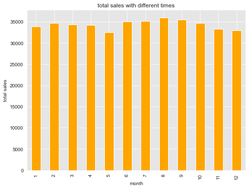

```python
d.index=d['month']
sns.set_style("darkgrid", {"axes.facecolor": ".9"})
plt.figure(figsize=(8,6))
d['total sales'].plot(kind='bar',color='orange')
plt.xlabel('month')
plt.ylabel("total sales")
plt.title('total sales with different times')
plt.rcParams['savefig.dpi'] = 300
plt.rcParams['figure.dpi'] = 300
#plt.savefig('1.png',dpi=900,bbox_inches='tight')  #存檔
plt.show()
```

可以看出：暑假銷售額最高

```python
e=c.groupby(["weekday"])['total sales'].sum().reset_index()
e
```

|  | weekday | total sales |
| --- | --- | --- |
| 0 | Friday | 9343694 |
| 1 | Monday | 8968860 |
| 2 | Saturday | 11383849 |
| 3 | Sunday | 11269626 |
| 4 | Thursday | 8245967 |
| 5 | Tuesday | 8290677 |
| 6 | Wednesday | 8192736 |

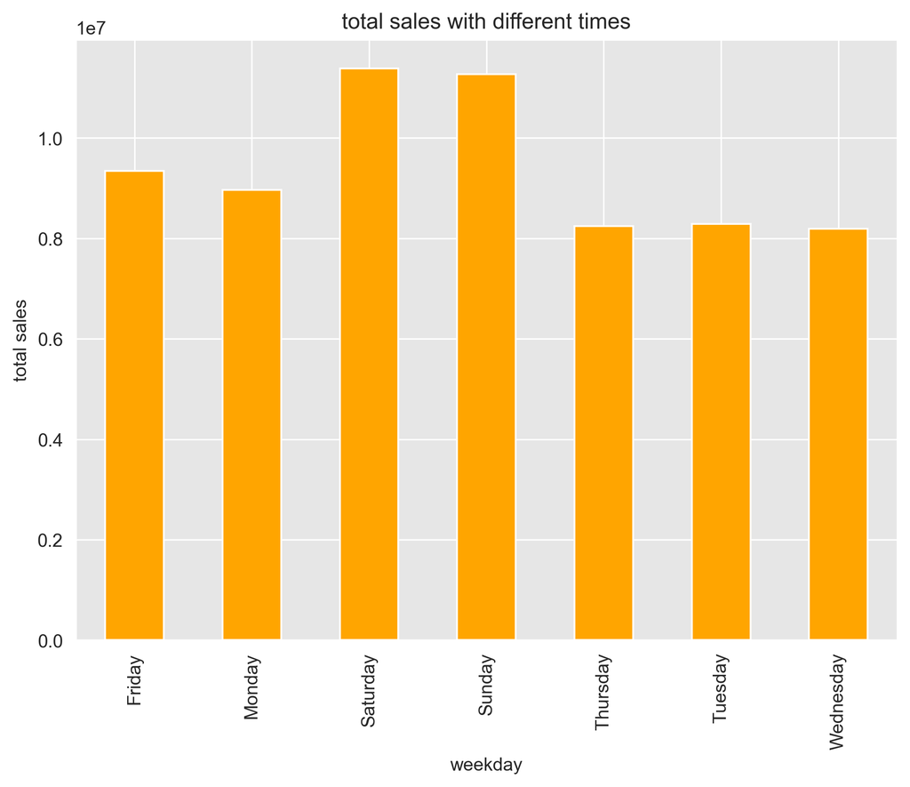

```python
e.index=e['weekday']
sns.set_style("darkgrid", {"axes.facecolor": ".9"})
plt.figure(figsize=(8,6))
e['total sales'].plot(kind='bar',color='orange')
plt.xlabel('weekday')
plt.ylabel("total sales")
plt.title('total sales with different times')
#plt.rcParams['savefig.dpi'] = 300
#plt.rcParams['figure.dpi'] = 300
#plt.savefig('1.png',dpi=900,bbox_inches='tight')  #存檔
plt.show()
```

可以看出：週末的銷售額最高

```python
f=c.groupby(["year"])['total sales'].mean().reset_index()
f
```

|  | year | total sales |
| --- | --- | --- |
| 0 | 2011 | 26280.667656 |
| 1 | 2012 | 32955.838798 |
| 2 | 2013 | 35988.364384 |
| 3 | 2014 | 35862.400000 |
| 4 | 2015 | 37810.441096 |
| 5 | 2016 | 41309.973913 |

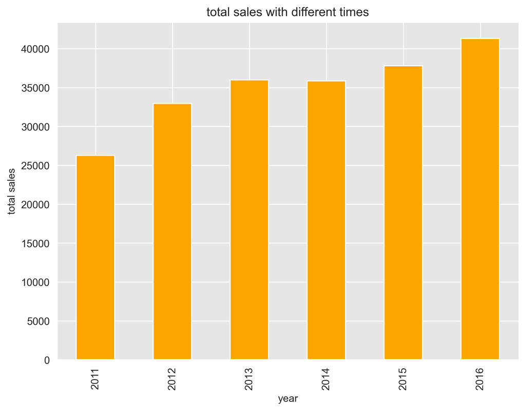

```python
f.index=f['year']
sns.set_style("darkgrid", {"axes.facecolor": ".9"})
plt.figure(figsize=(8,6))
f['total sales'].plot(kind='bar',color='orange')
plt.xlabel('year')
plt.ylabel("total sales")
plt.title('total sales with different times')
#plt.rcParams['savefig.dpi'] = 300
#plt.rcParams['figure.dpi'] = 300
#plt.savefig('1.png',dpi=900,bbox_inches='tight')  #存檔
plt.show()
```

```python
g=c.groupby(["wm_yr_wk"])['total sales'].sum().reset_index()
```

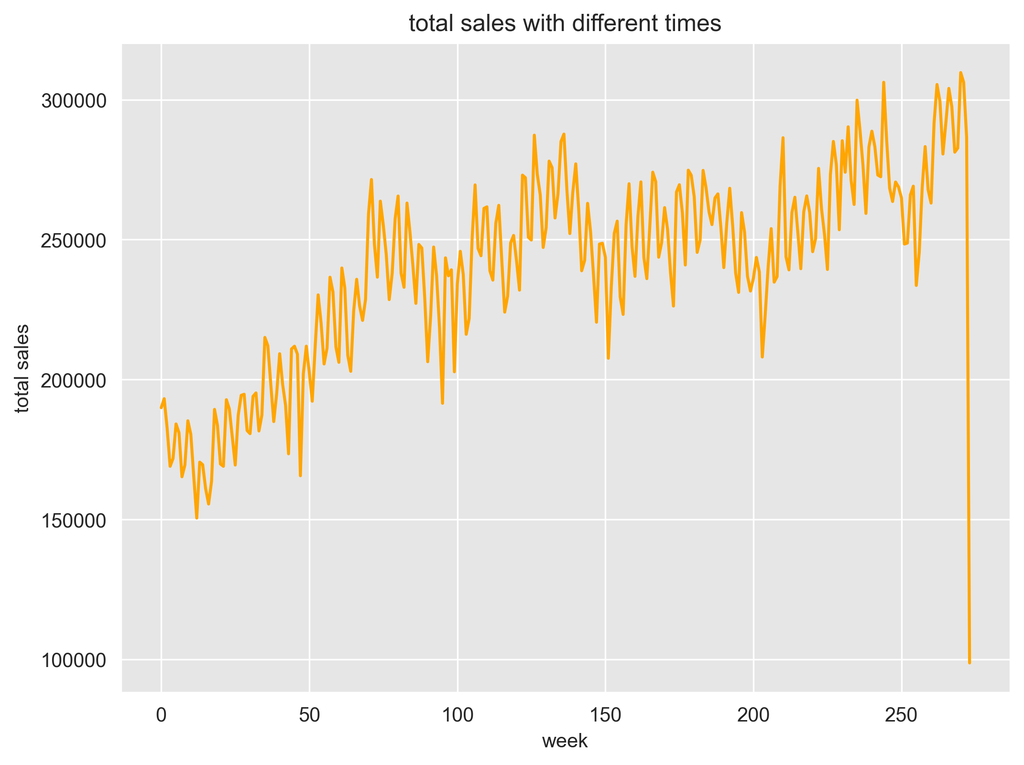

```python
sns.set_style("darkgrid", {"axes.facecolor": ".9"})
plt.figure(figsize=(8,6))
g['total sales'].plot(kind='line',color='orange')
plt.xlabel('week')
plt.ylabel("total sales")
plt.title('total sales with different times')
#plt.rcParams['savefig.dpi'] = 300
#plt.rcParams['figure.dpi'] = 300
#plt.savefig('1.png',dpi=900,bbox_inches='tight')  #存檔
plt.show()
```

### 剛剛是整體商品，現在細部拆開來，看到商品種類來做時間上的分析

```python
cate=sales.groupby('cat_id').sum()
cate2=cate.T.reset_index()
cate2=cate2.drop('index',axis=1)
category=pd.concat([b,cate2],axis=1)
category['date'] =  pd.to_datetime(category['date'], format='%Y-%m-%d')
```

```python
category
```

|  | date | wm_yr_wk | weekday | wday | month | year | d | event_name_1 | event_type_1 | event_name_2 | event_type_2 | snap_CA | snap_TX | snap_WI | FOODS | HOBBIES | HOUSEHOLD |
| --- | --- | --- | --- | --- | --- | --- | --- | --- | --- | --- | --- | --- | --- | --- | --- | --- | --- |
| 0 | 2011-01-29 | 11101 | Saturday | 1 | 1 | 2011 | d_1 | NaN | NaN | NaN | NaN | 0 | 0 | 0 | 23178 | 3764 | 5689 |
| 1 | 2011-01-30 | 11101 | Sunday | 2 | 1 | 2011 | d_2 | NaN | NaN | NaN | NaN | 0 | 0 | 0 | 22758 | 3357 | 5634 |
| 2 | 2011-01-31 | 11101 | Monday | 3 | 1 | 2011 | d_3 | NaN | NaN | NaN | NaN | 0 | 0 | 0 | 17174 | 2682 | 3927 |
| 3 | 2011-02-01 | 11101 | Tuesday | 4 | 2 | 2011 | d_4 | NaN | NaN | NaN | NaN | 1 | 1 | 0 | 18878 | 2669 | 3865 |
| 4 | 2011-02-02 | 11101 | Wednesday | 5 | 2 | 2011 | d_5 | NaN | NaN | NaN | NaN | 1 | 0 | 1 | 14603 | 1814 | 2729 |
| ... | ... | ... | ... | ... | ... | ... | ... | ... | ... | ... | ... | ... | ... | ... | ... | ... | ... |
| 1908 | 2016-04-20 | 11612 | Wednesday | 5 | 4 | 2016 | d_1909 | NaN | NaN | NaN | NaN | 0 | 0 | 0 | 23632 | 3472 | 8239 |
| 1909 | 2016-04-21 | 11612 | Thursday | 6 | 4 | 2016 | d_1910 | NaN | NaN | NaN | NaN | 0 | 0 | 0 | 23317 | 3353 | 8363 |
| 1910 | 2016-04-22 | 11612 | Friday | 7 | 4 | 2016 | d_1911 | NaN | NaN | NaN | NaN | 0 | 0 | 0 | 26704 | 4085 | 9728 |
| 1911 | 2016-04-23 | 11613 | Saturday | 1 | 4 | 2016 | d_1912 | NaN | NaN | NaN | NaN | 0 | 0 | 0 | 31927 | 4787 | 12248 |
| 1912 | 2016-04-24 | 11613 | Sunday | 2 | 4 | 2016 | d_1913 | NaN | NaN | NaN | NaN | 0 | 0 | 0 | 32654 | 4683 | 12458 |

1913 rows × 17 columns

```python
d_cate=category.groupby(["month"])[['FOODS','HOBBIES','HOUSEHOLD']].mean().reset_index()
d_cate
```

|  | month | FOODS | HOBBIES | HOUSEHOLD |
| --- | --- | --- | --- | --- |
| 0 | 1 | 23504.430380 | 3137.917722 | 7190.000000 |
| 1 | 2 | 23599.129412 | 3289.094118 | 7756.417647 |
| 2 | 3 | 23406.752688 | 3220.096774 | 7712.989247 |
| 3 | 4 | 23356.959770 | 3312.620690 | 7589.103448 |
| 4 | 5 | 22307.845161 | 3158.051613 | 7037.954839 |
| 5 | 6 | 24177.140000 | 3311.213333 | 7513.060000 |
| 6 | 7 | 24295.219355 | 3186.858065 | 7640.341935 |
| 7 | 8 | 24704.006452 | 3116.361290 | 8126.277419 |
| 8 | 9 | 24378.713333 | 3026.580000 | 8073.966667 |
| 9 | 10 | 23680.264516 | 3275.290323 | 7757.922581 |
| 10 | 11 | 22736.833333 | 3165.953333 | 7388.040000 |
| 11 | 12 | 22772.129032 | 3192.258065 | 7016.077419 |

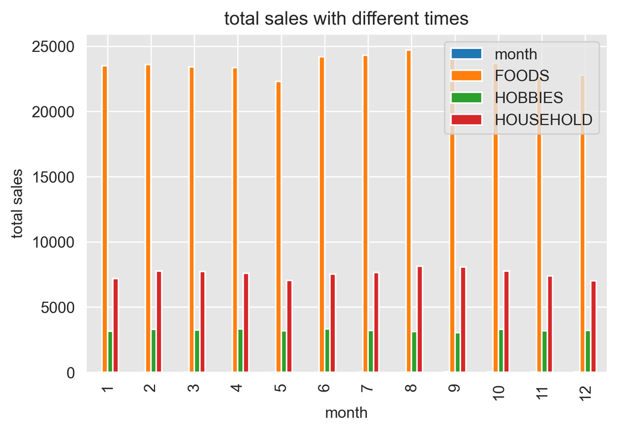

```python
d_cate.index=d_cate['month']
sns.set_style("darkgrid", {"axes.facecolor": ".9"})
plt.figure(figsize=(8,6))
d_cate.plot(kind='bar')
plt.xlabel('month')
plt.ylabel("total sales")
plt.title('total sales with different times')
#plt.rcParams['savefig.dpi'] = 300
#plt.rcParams['figure.dpi'] = 300
#plt.savefig('1.png',dpi=900,bbox_inches='tight')  #存檔
plt.show()
```

種類趨勢與整體差不多

```python
e_cate=category.groupby(["weekday"])[['FOODS','HOBBIES','HOUSEHOLD']].sum().reset_index()
e_cate
```

|  | weekday | FOODS | HOBBIES | HOUSEHOLD |
| --- | --- | --- | --- | --- |
| 0 | Friday | 6351112 | 907405 | 2085177 |
| 1 | Monday | 6206765 | 813632 | 1948463 |
| 2 | Saturday | 7693153 | 1076911 | 2613785 |
| 3 | Sunday | 7767048 | 976586 | 2525992 |
| 4 | Thursday | 5683848 | 786135 | 1775984 |
| 5 | Tuesday | 5736838 | 777821 | 1776018 |
| 6 | Wednesday | 5651175 | 786310 | 1755251 |

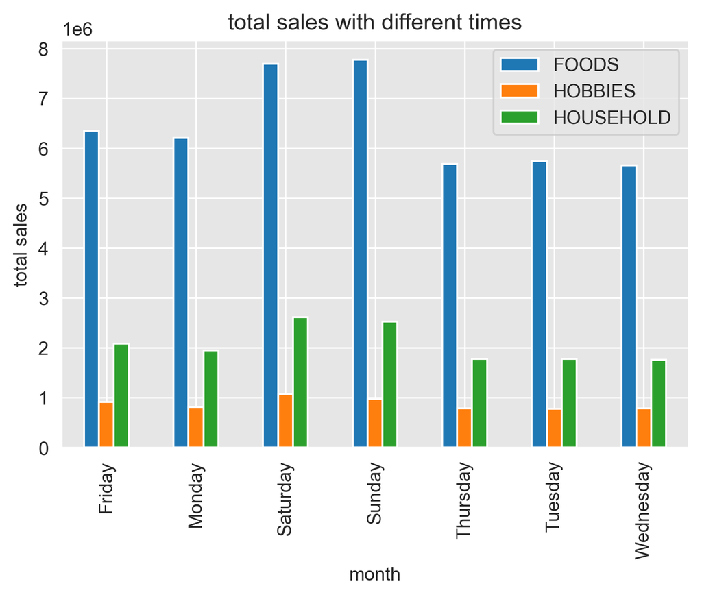

```python
e_cate.index=e_cate['weekday']
sns.set_style("darkgrid", {"axes.facecolor": ".9"})
plt.figure(figsize=(8,6))
e_cate.plot(kind='bar')
plt.xlabel('month')
plt.ylabel("total sales")
plt.title('total sales with different times')
#plt.rcParams['savefig.dpi'] = 300
#plt.rcParams['figure.dpi'] = 300
#plt.savefig('1.png',dpi=900,bbox_inches='tight')  #存檔
plt.show()
```

種類趨勢與整體差不多

```python
f_cate=category.groupby(["year"])[['FOODS','HOBBIES','HOUSEHOLD']].mean().reset_index()
f_cate
```

|  | year | FOODS | HOBBIES | HOUSEHOLD |
| --- | --- | --- | --- | --- |
| 0 | 2011 | 18572.296736 | 2786.798220 | 4921.572700 |
| 1 | 2012 | 23661.934426 | 2622.505464 | 6671.398907 |
| 2 | 2013 | 24634.197260 | 3309.750685 | 8044.416438 |
| 3 | 2014 | 24645.273973 | 3243.413699 | 7973.712329 |
| 4 | 2015 | 24695.493151 | 3808.643836 | 9306.304110 |
| 5 | 2016 | 27564.739130 | 3858.713043 | 9886.521739 |

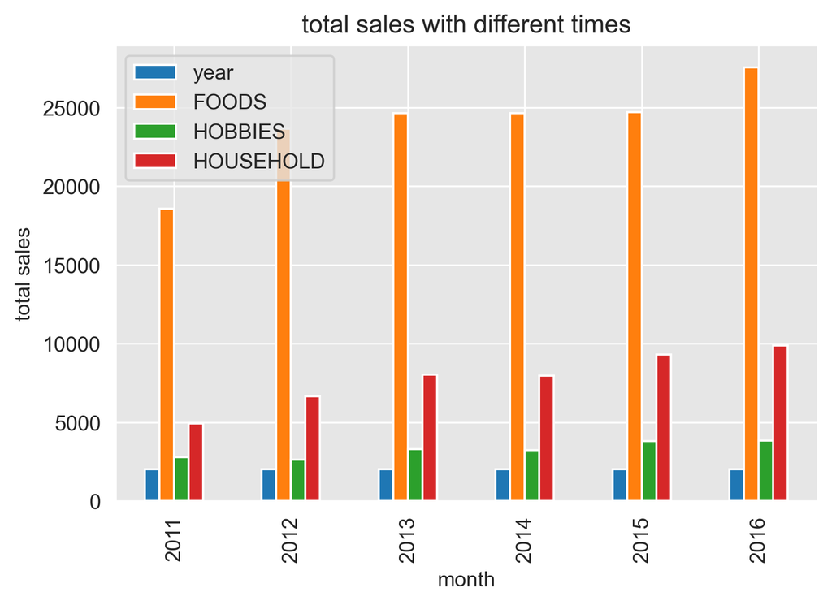

```python
f_cate.index=f_cate['year']
sns.set_style("darkgrid", {"axes.facecolor": ".9"})
plt.figure(figsize=(8,6))
f_cate.plot(kind='bar')
plt.xlabel('month')
plt.ylabel("total sales")
plt.title('total sales with different times')
#plt.rcParams['savefig.dpi'] = 300
#plt.rcParams['figure.dpi'] = 300
#plt.savefig('1.png',dpi=900,bbox_inches='tight')  #存檔
plt.show()
```

種類趨勢與整體差不多

```python
h_cate=category.groupby(["year","month"])[['FOODS','HOBBIES','HOUSEHOLD']].sum().reset_index()
```

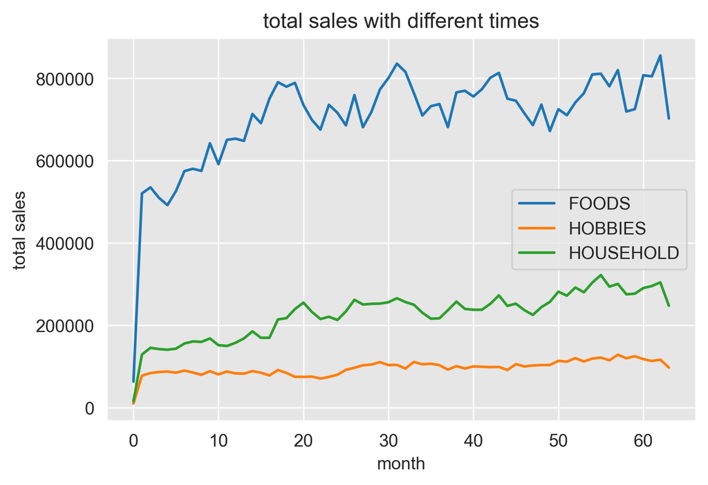

```python
sns.set_style("darkgrid", {"axes.facecolor": ".9"})
plt.figure(figsize=(8,6))
h_cate[['FOODS','HOBBIES','HOUSEHOLD']].plot(kind='line')
plt.xlabel('month')
plt.ylabel("total sales")
plt.title('total sales with different times')
#plt.rcParams['savefig.dpi'] = 300
#plt.rcParams['figure.dpi'] = 300
#plt.savefig('1.png',dpi=900,bbox_inches='tight')  #存檔
plt.show()
```

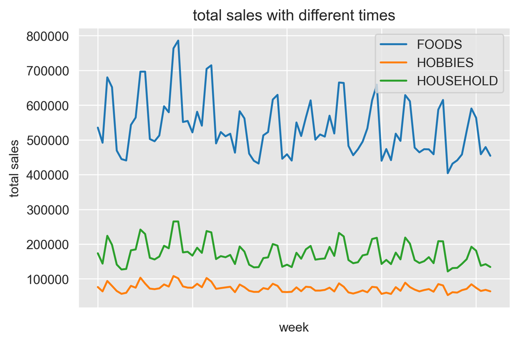

```python
#plt.rcParams.update(plt.rcParamsDefault)
i_cate.index=i['month-weekday']
sns.set_style("darkgrid", {"axes.facecolor": ".9"})
plt.figure(figsize=(8,6))
ax=i_cate[['FOODS','HOBBIES','HOUSEHOLD']].plot()
plt.xlabel('week')
plt.ylabel("total sales")
plt.title('total sales with different times')
ax.set_xticklabels('',size=7)
plt.rcParams['savefig.dpi'] = 300
plt.rcParams['figure.dpi'] = 300
#plt.savefig('1.png',dpi=900,bbox_inches='tight')  #存檔
plt.show()
```

## 做銷售量跟自己前幾期的銷售量有關的分析

```python
sales.head()
```

|  | id | item_id | dept_id | cat_id | store_id | state_id | d_1 | d_2 | d_3 | d_4 | d_5 | d_6 | d_7 | d_8 | d_9 | d_10 | d_11 | d_12 | d_13 | d_14 | d_15 | d_16 | d_17 | d_18 | d_19 | d_20 | d_21 | d_22 | d_23 | … |
| --- | --- | --- | --- | --- | --- | --- | --- | --- | --- | --- | --- | --- | --- | --- | --- | --- | --- | --- | --- | --- | --- | --- | --- | --- | --- | --- | --- | --- | --- | --- |
| 0 | HOBBIES_1_001_CA_1_validation | HOBBIES_1_001 | HOBBIES_1 | HOBBIES | CA_1 | CA | 0 | 0 | 0 | 0 | 0 | 0 | 0 | 0 | 0 | 0 | 0 | 0 | 0 | 0 | 0 | 0 | 0 | 0 | 0 | 0 | 0 | 0 | 0 | … |
| 1 | HOBBIES_1_002_CA_1_validation | HOBBIES_1_002 | HOBBIES_1 | HOBBIES | CA_1 | CA | 0 | 0 | 0 | 0 | 0 | 0 | 0 | 0 | 0 | 0 | 0 | 0 | 0 | 0 | 0 | 0 | 0 | 0 | 0 | 0 | 0 | 0 | 0 | … |
| 2 | HOBBIES_1_003_CA_1_validation | HOBBIES_1_003 | HOBBIES_1 | HOBBIES | CA_1 | CA | 0 | 0 | 0 | 0 | 0 | 0 | 0 | 0 | 0 | 0 | 0 | 0 | 0 | 0 | 0 | 0 | 0 | 0 | 0 | 0 | 0 | 0 | 0 | … |
| 3 | HOBBIES_1_004_CA_1_validation | HOBBIES_1_004 | HOBBIES_1 | HOBBIES | CA_1 | CA | 0 | 0 | 0 | 0 | 0 | 0 | 0 | 0 | 0 | 0 | 0 | 0 | 0 | 0 | 0 | 0 | 0 | 0 | 0 | 0 | 0 | 0 | 0 | … |
| 4 | HOBBIES_1_005_CA_1_validation | HOBBIES_1_005 | HOBBIES_1 | HOBBIES | CA_1 | CA | 0 | 0 | 0 | 0 | 0 | 0 | 0 | 0 | 0 | 0 | 0 | 0 | 0 | 0 | 0 | 0 | 0 | 0 | 0 | 0 | 0 | 0 | 0 | … |

5 rows × 1919 columns

```python
ww=sales[sales['state_id']=='TX']
ww= ww[sales['cat_id']=='FOODS']
www=ww.sum(axis=0)
www=pd.DataFrame(www)
www=www.reset_index()
www=www[6:]
www.columns=['day','sale']
www=www.reset_index().drop('index',axis=1)
www['sale']=www['sale'].astype('int')
www['t']=list(range(1,1914))
```

```python
from statsmodels.graphics.tsaplots import plot_pacf
from statsmodels.graphics.tsaplots import plot_acf
from scipy.stats import linregress
```

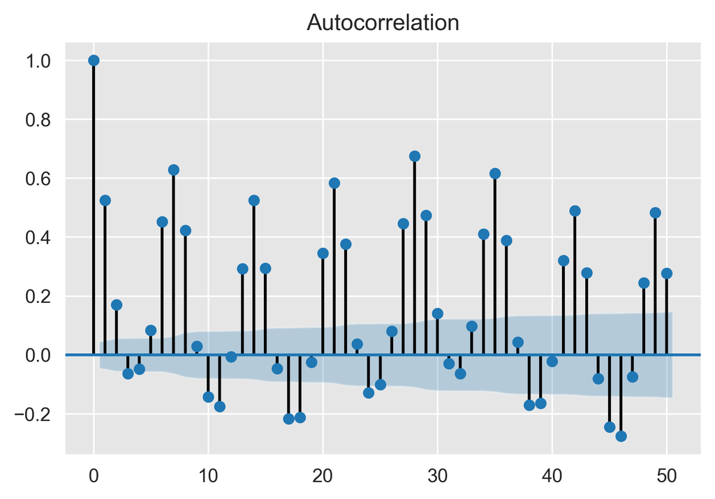

```python
plot_acf(www['sale'],lags=50)
plt.show()
```

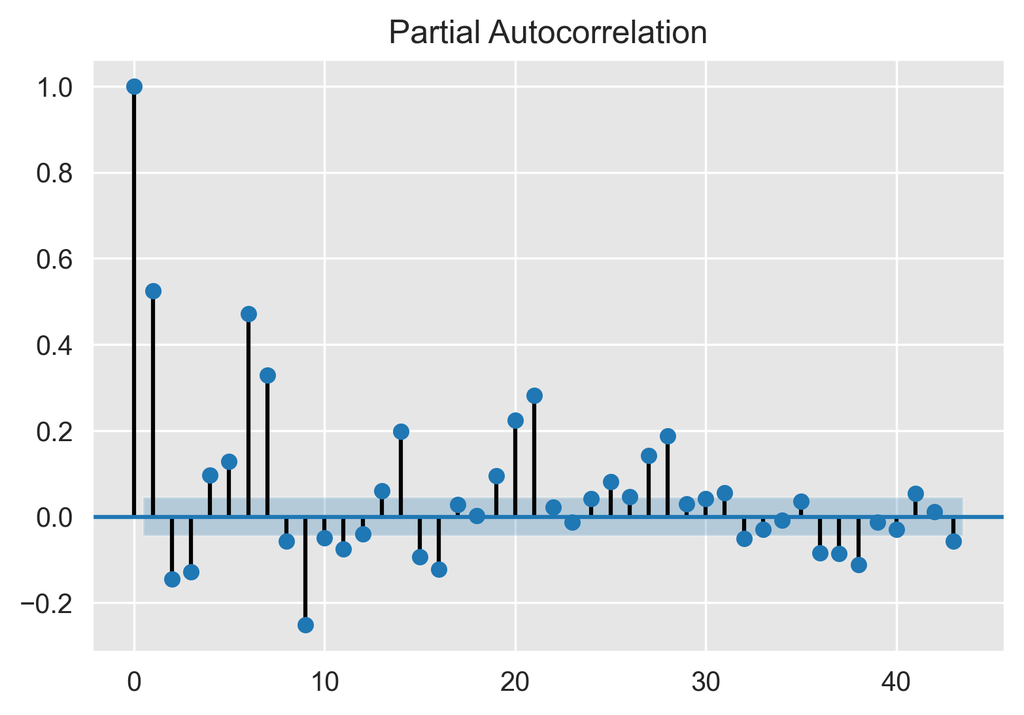

```python
plot_pacf(www['sale'],lags=43)
plt.show()
```

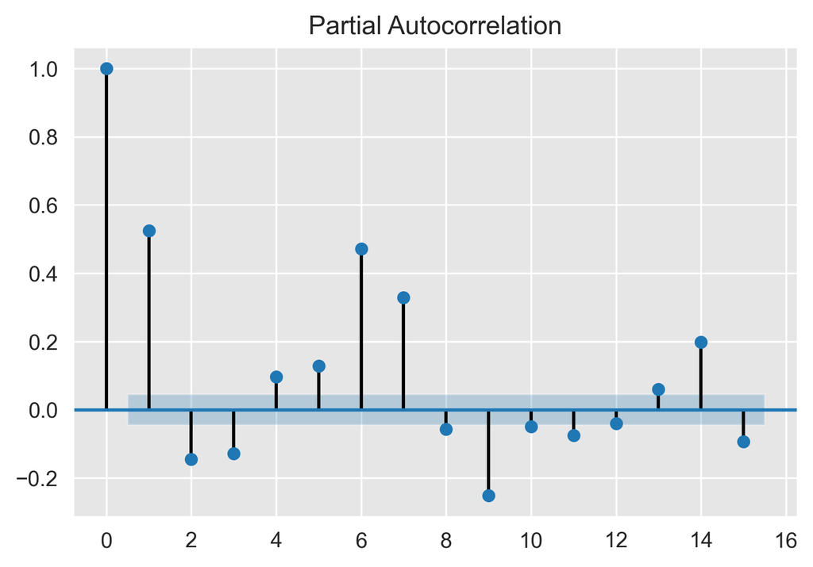

```python
plot_pacf(www['sale'],lags=15)
plt.show()
```

#### 所以可以看出當期銷售量可能會與上禮拜同一天的銷售量有高度的相關性

```python
import numpy as np
import pandas as pd
import matplotlib.pyplot as plt
import seaborn as sns
from google.colab import files
from google.colab import drive
drive.mount('/content/drive')
```

```python
data_dir = '/content/drive/My Drive/統計學習初論/Data/'
```

### EDA

snap vs 銷量

我們希望透過EDA探討snap(Supplemental Nutrition Assistance Program)的有無是否對銷量有影響，進而決定是否要將其作為預測的特徵之一

SNAP Program : https://www.feedingamerica.org/take-action/advocate/federal-hunger-relief-programs/snap

```python
sells_train = pd.read_csv(data_dir + "sales_train_validation.csv")
sells_train.head()
```

|  | id | item_id | dept_id | cat_id | store_id | state_id | d_1 | d_2 | d_3 | d_4 | d_5 | d_6 | d_7 | d_8 | d_9 | d_10 | d_11 | d_12 | d_13 | d_14 | d_15 | d_16 | d_17 | d_18 | d_19 | d_20 | d_21 | d_22 | d_23 | … |
| --- | --- | --- | --- | --- | --- | --- | --- | --- | --- | --- | --- | --- | --- | --- | --- | --- | --- | --- | --- | --- | --- | --- | --- | --- | --- | --- | --- | --- | --- | --- |
| 0 | HOBBIES_1_001_CA_1_validation | HOBBIES_1_001 | HOBBIES_1 | HOBBIES | CA_1 | CA | 0 | 0 | 0 | 0 | 0 | 0 | 0 | 0 | 0 | 0 | 0 | 0 | 0 | 0 | 0 | 0 | 0 | 0 | 0 | 0 | 0 | 0 | 0 | … |
| 1 | HOBBIES_1_002_CA_1_validation | HOBBIES_1_002 | HOBBIES_1 | HOBBIES | CA_1 | CA | 0 | 0 | 0 | 0 | 0 | 0 | 0 | 0 | 0 | 0 | 0 | 0 | 0 | 0 | 0 | 0 | 0 | 0 | 0 | 0 | 0 | 0 | 0 | … |
| 2 | HOBBIES_1_003_CA_1_validation | HOBBIES_1_003 | HOBBIES_1 | HOBBIES | CA_1 | CA | 0 | 0 | 0 | 0 | 0 | 0 | 0 | 0 | 0 | 0 | 0 | 0 | 0 | 0 | 0 | 0 | 0 | 0 | 0 | 0 | 0 | 0 | 0 | … |
| 3 | HOBBIES_1_004_CA_1_validation | HOBBIES_1_004 | HOBBIES_1 | HOBBIES | CA_1 | CA | 0 | 0 | 0 | 0 | 0 | 0 | 0 | 0 | 0 | 0 | 0 | 0 | 0 | 0 | 0 | 0 | 0 | 0 | 0 | 0 | 0 | 0 | 0 | … |
| 4 | HOBBIES_1_005_CA_1_validation | HOBBIES_1_005 | HOBBIES_1 | HOBBIES | CA_1 | CA | 0 | 0 | 0 | 0 | 0 | 0 | 0 | 0 | 0 | 0 | 0 | 0 | 0 | 0 | 0 | 0 | 0 | 0 | 0 | 0 | 0 | 0 | 0 | … |

5 rows × 1919 columns

```python
sells_train.shape
```

```
(30490, 1919)
```

由上可知，我們共有30490行資料，每個資料有1919個欄位，分別式商品基本的資料加上d_1 ~ d_1913的銷售量

以下讀取"calendar.csv"的資料

```python
calendar = pd.read_csv(data_dir + "calendar.csv")
calendar.head()
```

|  | date | wm_yr_wk | weekday | wday | month | year | d | event_name_1 | event_type_1 | event_name_2 | event_type_2 | snap_CA | snap_TX | snap_WI |
| --- | --- | --- | --- | --- | --- | --- | --- | --- | --- | --- | --- | --- | --- | --- |
| 0 | 2011-01-29 | 11101 | Saturday | 1 | 1 | 2011 | d_1 | NaN | NaN | NaN | NaN | 0 | 0 | 0 |
| 1 | 2011-01-30 | 11101 | Sunday | 2 | 1 | 2011 | d_2 | NaN | NaN | NaN | NaN | 0 | 0 | 0 |
| 2 | 2011-01-31 | 11101 | Monday | 3 | 1 | 2011 | d_3 | NaN | NaN | NaN | NaN | 0 | 0 | 0 |
| 3 | 2011-02-01 | 11101 | Tuesday | 4 | 2 | 2011 | d_4 | NaN | NaN | NaN | NaN | 1 | 1 | 0 |
| 4 | 2011-02-02 | 11101 | Wednesday | 5 | 2 | 2011 | d_5 | NaN | NaN | NaN | NaN | 1 | 0 | 1 |

```python
calendar.shape
```

```
(1969, 14)
```

**day_extraction(calendar, snap, state, end_day)**

根據parameters擷取指定的天數，回傳一個array包含這些天

- calendar : 使用的月曆data
- snap : 1 for snap = True, 0 for False
- state : "CA", "TX", or "WI"，三州中其中一州的資料(因為每個州的snap日期不同)
- end_day, default = 1913: 擷取的結束日期

```python
def day_extraction(calendar, snap, state, end_day = 1913):
    snap2value = lambda x: 1 if x==True else 0
    value = snap2value(snap)
    stateName = 'snap_' + state
    day_list = calendar[calendar[stateName] == value].loc[:, 'd'].values.tolist()
    for i in range(len(day_list)-1, 0, -1):
        if int(day_list[i][-4:]) > 1913:
            day_list.pop()
        else:
            break
    return np.array(day_list)
```

#### State vs snap

```python
state_list = sells_train['state_id'].value_counts().index.tolist()
days_list = []
mean_with_snap = []
mean_without_snap = []
for i in range(len(state_list)):
    days_list.append(day_extraction(calendar, snap = True, state = state_list[i]))
    days_list.append(day_extraction(calendar, snap = False, state = state_list[i]))
    mean_with_snap.append(sells_train[(sells_train['state_id'] == state_list[i])].loc[:, days_list[2*i]].mean().mean())
    mean_without_snap.append(sells_train[(sells_train['state_id'] == state_list[i])].loc[:, days_list[2*i+1]].mean().mean())

d = {'state' : state_list*2, 'mean' : mean_with_snap + mean_without_snap ,'snap':['With snap']*3 + ['Without snap']*3}
snap_df = pd.DataFrame(d)
```

```python
snap_df
```

|  | state | mean | snap |
| --- | --- | --- | --- |
| 0 | CA | 1.293202 | With snap |
| 1 | WI | 1.176733 | With snap |
| 2 | TX | 1.160242 | With snap |
| 3 | CA | 1.197590 | Without snap |
| 4 | WI | 0.966274 | Without snap |
| 5 | TX | 1.040678 | Without snap |

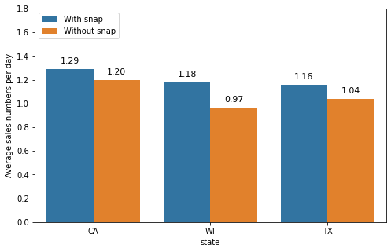

```python
plt.figure(figsize=(8, 5))
ax = sns.barplot(x="state", hue="snap", y="mean", data=snap_df)
ax.set_ylabel("Average sales numbers per day")
for p in ax.patches:
    ax.annotate("%.2f" % p.get_height(), (p.get_x() + p.get_width() / 2., p.get_height()),
         ha='center', va='center', fontsize=11, color='black', xytext=(0, 10),
         textcoords='offset points')
_ = ax.set_ylim(0,1.8)
plt.legend(loc='upper left')
plt.show()
plt.close()
```

```python
snap_compare = snap_df.iloc[:3, :2].copy()
snap_compare.columns = ['State', 'Mean_with_snap']
snap_compare['Mean_without_snap'] = snap_df.iloc[3:,1].tolist()
snap_compare['Growth with snap(%)'] = (snap_compare['Mean_with_snap'] /snap_compare['Mean_without_snap'] - 1)*100
snap_compare
```

|  | State | Mean_with_snap | Mean_without_snap | Growth with snap(%) |
| --- | --- | --- | --- | --- |
| 0 | CA | 1.293202 | 1.197590 | 7.983615 |
| 1 | WI | 1.176733 | 0.966274 | 21.780524 |
| 2 | TX | 1.160242 | 1.040678 | 11.489051 |

由上圖可知，snap對銷量在各州都是有正面影響的，只是程度上略有不同

##### Product category vs snap

看snap對每個州中的產品種類的銷量影響

```python
item_cat_list = sells_train['cat_id'].value_counts().index.tolist()
item_cat_list
```

```
['FOODS', 'HOUSEHOLD', 'HOBBIES']
```

```python
state_list = sells_train['state_id'].value_counts().index.tolist()
days_list = []
mean_with_snap = []
mean_without_snap = []
for i in range(len(state_list)):
    days_list.append(day_extraction(calendar, snap = True, state = state_list[i]))
    days_list.append(day_extraction(calendar, snap = False, state = state_list[i]))
    for j in range(len(item_cat_list)):
      mean_with_snap.append(sells_train[(sells_train['state_id'] == state_list[i]) & (sells_train['cat_id']==item_cat_list[j])]\
                            .loc[:, days_list[2*i]].mean().mean())
      mean_without_snap.append(sells_train[(sells_train['state_id'] == state_list[i])& (sells_train['cat_id']==item_cat_list[j])]\
                               .loc[:, days_list[2*i+1]].mean().mean())
```

```python
state_list_dup = state_list*3
state_list_dup.sort()
d = {'state' : state_list_dup*2, 'mean' : mean_with_snap + mean_without_snap ,'cat_id':item_cat_list*6, 'snap':['With snap']*9 + ['Without snap']*9}
snap_df = pd.DataFrame(d)
snap_df['state_cat_id'] = snap_df['state'] + '_' + snap_df['cat_id']
snap_df
```

|  | state | mean | cat_id | snap | state_cat_id |
| --- | --- | --- | --- | --- | --- |
| 0 | CA | 1.862391 | FOODS | With snap | CA_FOODS |
| 1 | CA | 0.822962 | HOUSEHOLD | With snap | CA_HOUSEHOLD |
| 2 | CA | 0.716944 | HOBBIES | With snap | CA_HOBBIES |
| 3 | TX | 1.855156 | FOODS | With snap | TX_FOODS |
| 4 | TX | 0.629186 | HOUSEHOLD | With snap | TX_HOUSEHOLD |
| 5 | TX | 0.465915 | HOBBIES | With snap | TX_HOBBIES |
| 6 | WI | 1.727489 | FOODS | With snap | WI_FOODS |
| 7 | WI | 0.739282 | HOUSEHOLD | With snap | WI_HOUSEHOLD |
| 8 | WI | 0.497606 | HOBBIES | With snap | WI_HOBBIES |
| 9 | CA | 1.688498 | FOODS | Without snap | CA_FOODS |
| 10 | CA | 0.794317 | HOUSEHOLD | Without snap | CA_HOUSEHOLD |
| 11 | CA | 0.696342 | HOBBIES | Without snap | CA_HOBBIES |
| 12 | TX | 1.428082 | FOODS | Without snap | TX_FOODS |
| 13 | TX | 0.606965 | HOUSEHOLD | Without snap | TX_HOUSEHOLD |
| 14 | TX | 0.457561 | HOBBIES | Without snap | TX_HOBBIES |
| 15 | WI | 1.494244 | FOODS | Without snap | WI_FOODS |
| 16 | WI | 0.716477 | HOUSEHOLD | Without snap | WI_HOUSEHOLD |
| 17 | WI | 0.487873 | HOBBIES | Without snap | WI_HOBBIES |

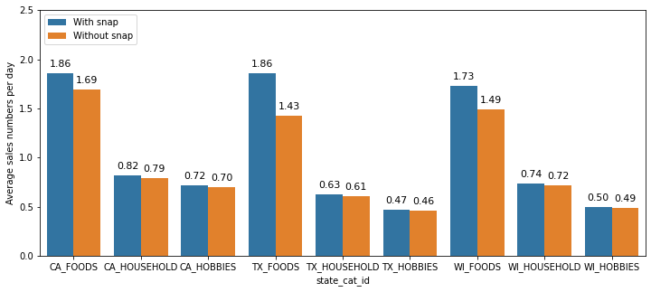

```python
plt.figure(figsize=(12, 5))
ax = sns.barplot(x="state_cat_id", hue="snap", y="mean", data=snap_df)
ax.set_ylabel("Average sales numbers per day")
for p in ax.patches:
    ax.annotate("%.2f" % p.get_height(), (p.get_x() + p.get_width() / 2., p.get_height()),
         ha='center', va='center', fontsize=11, color='black', xytext=(0, 10),
         textcoords='offset points')
_ = ax.set_ylim(0,2.5)
plt.legend(loc='upper left')
plt.show()
plt.close()
```

由上圖可以得知，snap主要只對FOODS的銷量有比較顯著的影響

#### Store vs snap

```python
stores = sells_train['store_id'].value_counts()
stores
```

```
CA_3    3049
WI_1    3049
TX_2    3049
WI_2    3049
TX_3    3049
CA_1    3049
CA_4    3049
WI_3    3049
TX_1    3049
CA_2    3049
Name: store_id, dtype: int64
```

```python
stores_id = stores.index.tolist()
stores_id.sort()

days_list = []
mean_with_snap = []
mean_without_snap = []
for i in range(len(stores_id)):
    state = stores_id[i][:2]
    days_list.append(day_extraction(calendar, snap = True, state = state ))
    days_list.append(day_extraction(calendar, snap = False, state = state))
    mean_with_snap.append(sells_train[(sells_train['store_id'] == stores_id[i])].loc[:, days_list[2*i]].mean().mean())
    mean_without_snap.append(sells_train[(sells_train['store_id'] == stores_id[i])].loc[:, days_list[2*i+1]].mean().mean())
# print(mean_with_snap)
# print(mean_without_snap)

stores_df = pd.DataFrame({'Store_id':stores_id*2, 'Mean':mean_with_snap + mean_without_snap, 'snap':['With snap']*10 + ['Without snap']*10})
```

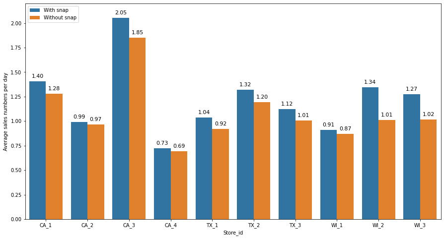

```python
plt.figure(figsize=(15, 8))
ax = sns.barplot(x="Store_id", hue="snap", y="Mean", data=stores_df)
ax.set_ylabel("Average sales numbers per day")
for p in ax.patches:
    ax.annotate("%.2f" % p.get_height(), (p.get_x() + p.get_width() / 2., p.get_height()),
         ha='center', va='center', fontsize=11, color='black', xytext=(0, 10),
         textcoords='offset points')
_ = ax.set_ylim(0,2.2)
plt.legend(loc='upper left')
plt.show()
plt.close()
```

```python
stores_compare_df = pd.DataFrame({'Store_id':stores_id, 'Mean_with_snap' : mean_with_snap, 'Mean_without_snap':mean_without_snap})
stores_compare_df['Growth with snap(%)'] =(stores_compare_df['Mean_with_snap']/stores_compare_df['Mean_without_snap']-1)*100
stores_compare_df
```

|  | Store_id | Mean_with_snap | Mean_without_snap | Growth with snap(%) |
| --- | --- | --- | --- | --- |
| 0 | CA_1 | 1.404695 | 1.278157 | 9.900020 |
| 1 | CA_2 | 0.989801 | 0.967363 | 2.319564 |
| 2 | CA_3 | 2.053171 | 1.851879 | 10.869611 |
| 3 | CA_4 | 0.725139 | 0.692963 | 4.643196 |
| 4 | TX_1 | 1.037879 | 0.920702 | 12.726939 |
| 5 | TX_2 | 1.319730 | 1.196195 | 10.327314 |
| 6 | TX_3 | 1.123118 | 1.005138 | 11.737714 |
| 7 | WI_1 | 0.911159 | 0.868855 | 4.868974 |
| 8 | WI_2 | 1.344542 | 1.012642 | 32.775676 |
| 9 | WI_3 | 1.274498 | 1.017324 | 25.279434 |

由上圖可知，大部分的商店是會受到snap的有無而影響到銷售量的，但有些幅度較大，有些還好

#### **結論**

無論從州別、商品別、或商店別來看，我們都可以發現snap的有無跟銷量是有關連性的，所以snap應為一個有效的資訊。在做預測時，應該要將snap作為特徵，以提高模型的準確率。

```python
import numpy as np
import pandas as pd
import matplotlib.pyplot as plt
import seaborn as sns
from google.colab import files
from google.colab import drive
drive.mount('/content/drive')
```

```python
data_dir = '/content/drive/My Drive/統計學習初論/Data/'
```

#### Load data

```python
sells_train = pd.read_csv(data_dir + "sales_train_validation.csv")
sells_train.head()
```

|  | id | item_id | dept_id | cat_id | store_id | state_id | d_1 | d_2 | d_3 | d_4 | d_5 | d_6 | d_7 | d_8 | d_9 | d_10 | d_11 | d_12 | d_13 | d_14 | d_15 | d_16 | d_17 | d_18 | d_19 | d_20 | d_21 | d_22 | d_23 | … |
| --- | --- | --- | --- | --- | --- | --- | --- | --- | --- | --- | --- | --- | --- | --- | --- | --- | --- | --- | --- | --- | --- | --- | --- | --- | --- | --- | --- | --- | --- | --- |
| 0 | HOBBIES_1_001_CA_1_validation | HOBBIES_1_001 | HOBBIES_1 | HOBBIES | CA_1 | CA | 0 | 0 | 0 | 0 | 0 | 0 | 0 | 0 | 0 | 0 | 0 | 0 | 0 | 0 | 0 | 0 | 0 | 0 | 0 | 0 | 0 | 0 | 0 | … |
| 1 | HOBBIES_1_002_CA_1_validation | HOBBIES_1_002 | HOBBIES_1 | HOBBIES | CA_1 | CA | 0 | 0 | 0 | 0 | 0 | 0 | 0 | 0 | 0 | 0 | 0 | 0 | 0 | 0 | 0 | 0 | 0 | 0 | 0 | 0 | 0 | 0 | 0 | … |
| 2 | HOBBIES_1_003_CA_1_validation | HOBBIES_1_003 | HOBBIES_1 | HOBBIES | CA_1 | CA | 0 | 0 | 0 | 0 | 0 | 0 | 0 | 0 | 0 | 0 | 0 | 0 | 0 | 0 | 0 | 0 | 0 | 0 | 0 | 0 | 0 | 0 | 0 | … |
| 3 | HOBBIES_1_004_CA_1_validation | HOBBIES_1_004 | HOBBIES_1 | HOBBIES | CA_1 | CA | 0 | 0 | 0 | 0 | 0 | 0 | 0 | 0 | 0 | 0 | 0 | 0 | 0 | 0 | 0 | 0 | 0 | 0 | 0 | 0 | 0 | 0 | 0 | … |
| 4 | HOBBIES_1_005_CA_1_validation | HOBBIES_1_005 | HOBBIES_1 | HOBBIES | CA_1 | CA | 0 | 0 | 0 | 0 | 0 | 0 | 0 | 0 | 0 | 0 | 0 | 0 | 0 | 0 | 0 | 0 | 0 | 0 | 0 | 0 | 0 | 0 | 0 | … |

5 rows × 1919 columns

```python
sells_train.shape
```

```
(30490, 1919)
```

```python
calendar = pd.read_csv(data_dir + "calendar.csv")
calendar.head()
```

|  | date | wm_yr_wk | weekday | wday | month | year | d | event_name_1 | event_type_1 | event_name_2 | event_type_2 | snap_CA | snap_TX | snap_WI |
| --- | --- | --- | --- | --- | --- | --- | --- | --- | --- | --- | --- | --- | --- | --- |
| 0 | 2011-01-29 | 11101 | Saturday | 1 | 1 | 2011 | d_1 | NaN | NaN | NaN | NaN | 0 | 0 | 0 |
| 1 | 2011-01-30 | 11101 | Sunday | 2 | 1 | 2011 | d_2 | NaN | NaN | NaN | NaN | 0 | 0 | 0 |
| 2 | 2011-01-31 | 11101 | Monday | 3 | 1 | 2011 | d_3 | NaN | NaN | NaN | NaN | 0 | 0 | 0 |
| 3 | 2011-02-01 | 11101 | Tuesday | 4 | 2 | 2011 | d_4 | NaN | NaN | NaN | NaN | 1 | 1 | 0 |
| 4 | 2011-02-02 | 11101 | Wednesday | 5 | 2 | 2011 | d_5 | NaN | NaN | NaN | NaN | 1 | 0 | 1 |

```python
calendar.shape
```

```
(1969, 14)
```

```python
sell_prices = pd.read_csv(data_dir + "sell_prices.csv")
print(sell_prices.shape)
sell_prices.head()
```

```
(6841121, 4)
```

|  | store_id | item_id | wm_yr_wk | sell_price |
| --- | --- | --- | --- | --- |
| 0 | CA_1 | HOBBIES_1_001 | 11325 | 9.58 |
| 1 | CA_1 | HOBBIES_1_001 | 11326 | 9.58 |
| 2 | CA_1 | HOBBIES_1_001 | 11327 | 8.26 |
| 3 | CA_1 | HOBBIES_1_001 | 11328 | 8.26 |
| 4 | CA_1 | HOBBIES_1_001 | 11329 | 8.26 |

```python
sell_prices.set_index(['store_id', 'item_id', 'wm_yr_wk'], inplace=True)
sell_prices.head()
```

| store_id | item_id | wm_yr_wk | sell_price |
| --- | --- | --- | --- |
| CA_1 | HOBBIES_1_001 | 11325 | 9.58 |
|  |  | 11326 | 9.58 |
|  |  | 11327 | 8.26 |
|  |  | 11328 | 8.26 |
|  |  | 11329 | 8.26 |

### Build training dataframe

```python
id_order = sells_train['id'].tolist()
id_order[:10]
```

```
['HOBBIES_1_001_CA_1_validation',
 'HOBBIES_1_002_CA_1_validation',
 'HOBBIES_1_003_CA_1_validation',
 'HOBBIES_1_004_CA_1_validation',
 'HOBBIES_1_005_CA_1_validation',
 'HOBBIES_1_006_CA_1_validation',
 'HOBBIES_1_007_CA_1_validation',
 'HOBBIES_1_008_CA_1_validation',
 'HOBBIES_1_009_CA_1_validation',
 'HOBBIES_1_010_CA_1_validation']
```

```python
day_num = 1913
basic_data = sells_train.iloc[:, :6].copy()
duplicate = [basic_data]*day_num
basic_data = pd.concat(duplicate)
basic_data['id'] = basic_data['id'].astype('category')
basic_data['id'] = basic_data['id'].cat.set_categories(id_order)
basic_data = basic_data.sort_values(by = ['id']).reset_index(drop = True)
basic_data.head()
```

|  | id | item_id | dept_id | cat_id | store_id | state_id |
| --- | --- | --- | --- | --- | --- | --- |
| 0 | HOBBIES_1_001_CA_1_validation | HOBBIES_1_001 | HOBBIES_1 | HOBBIES | CA_1 | CA |
| 1 | HOBBIES_1_001_CA_1_validation | HOBBIES_1_001 | HOBBIES_1 | HOBBIES | CA_1 | CA |
| 2 | HOBBIES_1_001_CA_1_validation | HOBBIES_1_001 | HOBBIES_1 | HOBBIES | CA_1 | CA |
| 3 | HOBBIES_1_001_CA_1_validation | HOBBIES_1_001 | HOBBIES_1 | HOBBIES | CA_1 | CA |
| 4 | HOBBIES_1_001_CA_1_validation | HOBBIES_1_001 | HOBBIES_1 | HOBBIES | CA_1 | CA |

```python
day_name = sells_train.columns[6:].tolist()
day_name[:10]
```

```
['d_1', 'd_2', 'd_3', 'd_4', 'd_5', 'd_6', 'd_7', 'd_8', 'd_9', 'd_10']
```

```python
sample_num = len(sells_train)
basic_data['d'] = day_name*sample_num
basic_data.head()
```

|  | id | item_id | dept_id | cat_id | store_id | state_id | d |
| --- | --- | --- | --- | --- | --- | --- | --- |
| 0 | HOBBIES_1_001_CA_1_validation | HOBBIES_1_001 | HOBBIES_1 | HOBBIES | CA_1 | CA | d_1 |
| 1 | HOBBIES_1_001_CA_1_validation | HOBBIES_1_001 | HOBBIES_1 | HOBBIES | CA_1 | CA | d_2 |
| 2 | HOBBIES_1_001_CA_1_validation | HOBBIES_1_001 | HOBBIES_1 | HOBBIES | CA_1 | CA | d_3 |
| 3 | HOBBIES_1_001_CA_1_validation | HOBBIES_1_001 | HOBBIES_1 | HOBBIES | CA_1 | CA | d_4 |
| 4 | HOBBIES_1_001_CA_1_validation | HOBBIES_1_001 | HOBBIES_1 | HOBBIES | CA_1 | CA | d_5 |

```python
sell_amt = np.reshape(sells_train.iloc[:, 6:].values, (day_num*sample_num, 1))
basic_data['num_sold'] = sell_amt
basic_data.head()
```

|  | id | item_id | dept_id | cat_id | store_id | state_id | d | num_sold |
| --- | --- | --- | --- | --- | --- | --- | --- | --- |
| 0 | HOBBIES_1_001_CA_1_validation | HOBBIES_1_001 | HOBBIES_1 | HOBBIES | CA_1 | CA | d_1 | 0 |
| 1 | HOBBIES_1_001_CA_1_validation | HOBBIES_1_001 | HOBBIES_1 | HOBBIES | CA_1 | CA | d_2 | 0 |
| 2 | HOBBIES_1_001_CA_1_validation | HOBBIES_1_001 | HOBBIES_1 | HOBBIES | CA_1 | CA | d_3 | 0 |
| 3 | HOBBIES_1_001_CA_1_validation | HOBBIES_1_001 | HOBBIES_1 | HOBBIES | CA_1 | CA | d_4 | 0 |
| 4 | HOBBIES_1_001_CA_1_validation | HOBBIES_1_001 | HOBBIES_1 | HOBBIES | CA_1 | CA | d_5 | 0 |

```python
basic_data.shape
```

```
(58327370, 8)
```

```python
cal_df = pd.concat([calendar.iloc[:1913]]*sample_num).reset_index(drop=True)
cal_df
```

|  | date | wm_yr_wk | weekday | wday | month | year | d | event_name_1 | event_type_1 | event_name_2 | event_type_2 | snap_CA | snap_TX | snap_WI |
| --- | --- | --- | --- | --- | --- | --- | --- | --- | --- | --- | --- | --- | --- | --- |
| 0 | 2011-01-29 | 11101 | Saturday | 1 | 1 | 2011 | d_1 | NaN | NaN | NaN | NaN | 0 | 0 | 0 |
| 1 | 2011-01-30 | 11101 | Sunday | 2 | 1 | 2011 | d_2 | NaN | NaN | NaN | NaN | 0 | 0 | 0 |
| 2 | 2011-01-31 | 11101 | Monday | 3 | 1 | 2011 | d_3 | NaN | NaN | NaN | NaN | 0 | 0 | 0 |
| 3 | 2011-02-01 | 11101 | Tuesday | 4 | 2 | 2011 | d_4 | NaN | NaN | NaN | NaN | 1 | 1 | 0 |
| 4 | 2011-02-02 | 11101 | Wednesday | 5 | 2 | 2011 | d_5 | NaN | NaN | NaN | NaN | 1 | 0 | 1 |
| ... | ... | ... | ... | ... | ... | ... | ... | ... | ... | ... | ... | ... | ... | ... |
| 58327365 | 2016-04-20 | 11612 | Wednesday | 5 | 4 | 2016 | d_1909 | NaN | NaN | NaN | NaN | 0 | 0 | 0 |
| 58327366 | 2016-04-21 | 11612 | Thursday | 6 | 4 | 2016 | d_1910 | NaN | NaN | NaN | NaN | 0 | 0 | 0 |
| 58327367 | 2016-04-22 | 11612 | Friday | 7 | 4 | 2016 | d_1911 | NaN | NaN | NaN | NaN | 0 | 0 | 0 |
| 58327368 | 2016-04-23 | 11613 | Saturday | 1 | 4 | 2016 | d_1912 | NaN | NaN | NaN | NaN | 0 | 0 | 0 |
| 58327369 | 2016-04-24 | 11613 | Sunday | 2 | 4 | 2016 | d_1913 | NaN | NaN | NaN | NaN | 0 | 0 | 0 |

58327370 rows × 14 columns

```python
cal_df.drop(['wday','d'], axis=1, inplace = True)
```

```python
cal_df.shape
```

```
(58327370, 12)
```

```python
train_data = pd.concat([basic_data, cal_df], axis=1)
train_data.head()
```

|  | id | item_id | dept_id | cat_id | store_id | state_id | d | num_sold | date | wm_yr_wk | weekday | month | year | event_name_1 | event_type_1 | event_name_2 | event_type_2 | snap_CA | snap_TX | snap_WI |
| --- | --- | --- | --- | --- | --- | --- | --- | --- | --- | --- | --- | --- | --- | --- | --- | --- | --- | --- | --- | --- |
| 0 | HOBBIES_1_001_CA_1_validation | HOBBIES_1_001 | HOBBIES_1 | HOBBIES | CA_1 | CA | d_1 | 0 | 2011-01-29 | 11101 | Saturday | 1 | 2011 | NaN | NaN | NaN | NaN | 0 | 0 | 0 |
| 1 | HOBBIES_1_001_CA_1_validation | HOBBIES_1_001 | HOBBIES_1 | HOBBIES | CA_1 | CA | d_2 | 0 | 2011-01-30 | 11101 | Sunday | 1 | 2011 | NaN | NaN | NaN | NaN | 0 | 0 | 0 |
| 2 | HOBBIES_1_001_CA_1_validation | HOBBIES_1_001 | HOBBIES_1 | HOBBIES | CA_1 | CA | d_3 | 0 | 2011-01-31 | 11101 | Monday | 1 | 2011 | NaN | NaN | NaN | NaN | 0 | 0 | 0 |
| 3 | HOBBIES_1_001_CA_1_validation | HOBBIES_1_001 | HOBBIES_1 | HOBBIES | CA_1 | CA | d_4 | 0 | 2011-02-01 | 11101 | Tuesday | 2 | 2011 | NaN | NaN | NaN | NaN | 1 | 1 | 0 |
| 4 | HOBBIES_1_001_CA_1_validation | HOBBIES_1_001 | HOBBIES_1 | HOBBIES | CA_1 | CA | d_5 | 0 | 2011-02-02 | 11101 | Wednesday | 2 | 2011 | NaN | NaN | NaN | NaN | 1 | 0 | 1 |

```python
train_data.shape
```

```
(58327370, 20)
```

```python
import gc
gc.collect()
```

```
22
```

#### Snap and state

```python
state2snap = lambda x: x['snap_CA'] if x['state_id'] == 'CA' else(x['snap_TX'] if x['state_id']=='TX' else x['snap_WI'])
```

```python
snap = train_data[['snap_CA', 'snap_TX', 'snap_WI', 'state_id']].apply(state2snap, axis=1)
snap
```

```python
train_data.drop(['snap_CA', 'snap_TX', 'snap_WI'], inplace = True, axis=1)
```

```python
train_data.head()
```

[output not shown]

#### 下面function要改

```python
def get_price(df):
  wm_yr_wk = df['wm_yr_wk']
  store_id = df['store_id']
  item_id = df['item_id']
  return sell_prices.loc[store_id, item_id, wm_yr_wk]['sell_price']
```

```python
train_data['sell_price'] = train_data.apply(get_price, axis=1)
train_data.head()
```

```python
import numpy as np
import pandas as pd
import matplotlib.pyplot as plt
import seaborn as sns
```

```python
data=pd.read_csv('item1.csv')
```

```python
data
```

|  | id | item_id | dept_id | cat_id | store_id | state_id | d | num_sold | date | wm_yr_wk | weekday | month | year | event_name_1 | event_type_1 | event_name_2 | event_type_2 | snap | sell_price |
| --- | --- | --- | --- | --- | --- | --- | --- | --- | --- | --- | --- | --- | --- | --- | --- | --- | --- | --- | --- |
| 0 | HOBBIES_1_001_CA_1_validation | HOBBIES_1_001 | HOBBIES_1 | HOBBIES | CA_1 | CA | d_1 | 0 | 2011-01-29 | 11101 | Saturday | 1 | 2011 | NaN | NaN | NaN | NaN | 0 | 9.58 |
| 1 | HOBBIES_1_001_CA_1_validation | HOBBIES_1_001 | HOBBIES_1 | HOBBIES | CA_1 | CA | d_2 | 0 | 2011-01-30 | 11101 | Sunday | 1 | 2011 | NaN | NaN | NaN | NaN | 0 | 9.58 |
| 2 | HOBBIES_1_001_CA_1_validation | HOBBIES_1_001 | HOBBIES_1 | HOBBIES | CA_1 | CA | d_3 | 0 | 2011-01-31 | 11101 | Monday | 1 | 2011 | NaN | NaN | NaN | NaN | 0 | 9.58 |
| 3 | HOBBIES_1_001_CA_1_validation | HOBBIES_1_001 | HOBBIES_1 | HOBBIES | CA_1 | CA | d_4 | 0 | 2011-02-01 | 11101 | Tuesday | 2 | 2011 | NaN | NaN | NaN | NaN | 1 | 9.58 |
| 4 | HOBBIES_1_001_CA_1_validation | HOBBIES_1_001 | HOBBIES_1 | HOBBIES | CA_1 | CA | d_5 | 0 | 2011-02-02 | 11101 | Wednesday | 2 | 2011 | NaN | NaN | NaN | NaN | 1 | 9.58 |
| ... | ... | ... | ... | ... | ... | ... | ... | ... | ... | ... | ... | ... | ... | ... | ... | ... | ... | ... | ... |
| 1908 | HOBBIES_1_001_CA_1_validation | HOBBIES_1_001 | HOBBIES_1 | HOBBIES | CA_1 | CA | d_1909 | 1 | 2016-04-20 | 11612 | Wednesday | 4 | 2016 | NaN | NaN | NaN | NaN | 0 | 8.38 |
| 1909 | HOBBIES_1_001_CA_1_validation | HOBBIES_1_001 | HOBBIES_1 | HOBBIES | CA_1 | CA | d_1910 | 3 | 2016-04-21 | 11612 | Thursday | 4 | 2016 | NaN | NaN | NaN | NaN | 0 | 8.38 |
| 1910 | HOBBIES_1_001_CA_1_validation | HOBBIES_1_001 | HOBBIES_1 | HOBBIES | CA_1 | CA | d_1911 | 0 | 2016-04-22 | 11612 | Friday | 4 | 2016 | NaN | NaN | NaN | NaN | 0 | 8.38 |
| 1911 | HOBBIES_1_001_CA_1_validation | HOBBIES_1_001 | HOBBIES_1 | HOBBIES | CA_1 | CA | d_1912 | 1 | 2016-04-23 | 11613 | Saturday | 4 | 2016 | NaN | NaN | NaN | NaN | 0 | 8.38 |
| 1912 | HOBBIES_1_001_CA_1_validation | HOBBIES_1_001 | HOBBIES_1 | HOBBIES | CA_1 | CA | d_1913 | 1 | 2016-04-24 | 11613 | Sunday | 4 | 2016 | NaN | NaN | NaN | NaN | 0 | 8.38 |

1913 rows × 19 columns

```python
data.info()
```

```
<class 'pandas.core.frame.DataFrame'>
RangeIndex: 1913 entries, 0 to 1912
Data columns (total 19 columns):
 #   Column        Non-Null Count  Dtype
---  ------        --------------  -----
 0   id            1913 non-null   object
 1   item_id       1913 non-null   object
 2   dept_id       1913 non-null   object
 3   cat_id        1913 non-null   object
 4   store_id      1913 non-null   object
 5   state_id      1913 non-null   object
 6   d             1913 non-null   object
 7   num_sold      1913 non-null   int64
 8   date          1913 non-null   object
 9   wm_yr_wk      1913 non-null   int64
 10  weekday       1913 non-null   object
 11  month         1913 non-null   int64
 12  year          1913 non-null   int64
 13  event_name_1  154 non-null    object
 14  event_type_1  154 non-null    object
 15  event_name_2  4 non-null      object
 16  event_type_2  4 non-null      object
 17  snap          1913 non-null   int64
 18  sell_price    1913 non-null   float64
dtypes: float64(1), int64(5), object(13)
memory usage: 284.1+ KB
```

```python
dataset=data
```

```python
dataset.head()
```

|  | id | item_id | dept_id | cat_id | store_id | state_id | d | num_sold | date | wm_yr_wk | weekday | month | year | event_name_1 | event_type_1 | event_name_2 | event_type_2 | snap | sell_price |
| --- | --- | --- | --- | --- | --- | --- | --- | --- | --- | --- | --- | --- | --- | --- | --- | --- | --- | --- | --- |
| 0 | HOBBIES_1_001_CA_1_validation | HOBBIES_1_001 | HOBBIES_1 | HOBBIES | CA_1 | CA | d_1 | 0 | 2011-01-29 | 11101 | Saturday | 1 | 2011 | NaN | NaN | NaN | NaN | 0 | 9.58 |
| 1 | HOBBIES_1_001_CA_1_validation | HOBBIES_1_001 | HOBBIES_1 | HOBBIES | CA_1 | CA | d_2 | 0 | 2011-01-30 | 11101 | Sunday | 1 | 2011 | NaN | NaN | NaN | NaN | 0 | 9.58 |
| 2 | HOBBIES_1_001_CA_1_validation | HOBBIES_1_001 | HOBBIES_1 | HOBBIES | CA_1 | CA | d_3 | 0 | 2011-01-31 | 11101 | Monday | 1 | 2011 | NaN | NaN | NaN | NaN | 0 | 9.58 |
| 3 | HOBBIES_1_001_CA_1_validation | HOBBIES_1_001 | HOBBIES_1 | HOBBIES | CA_1 | CA | d_4 | 0 | 2011-02-01 | 11101 | Tuesday | 2 | 2011 | NaN | NaN | NaN | NaN | 1 | 9.58 |
| 4 | HOBBIES_1_001_CA_1_validation | HOBBIES_1_001 | HOBBIES_1 | HOBBIES | CA_1 | CA | d_5 | 0 | 2011-02-02 | 11101 | Wednesday | 2 | 2011 | NaN | NaN | NaN | NaN | 1 | 9.58 |

```python
df=dataset[['date','num_sold']]
```

```python
df['date'] =  pd.to_datetime(df['date'] , format='%Y-%m-%d')
```

```python
df=df.set_index('date')
```

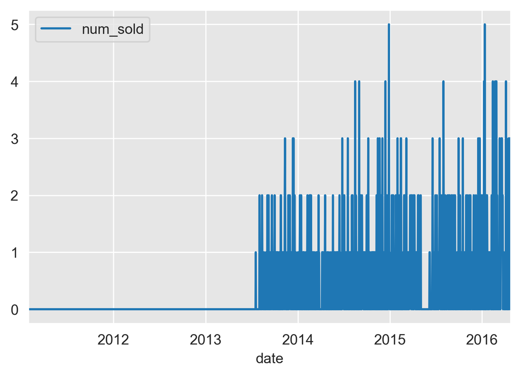

```python
df.plot()
```

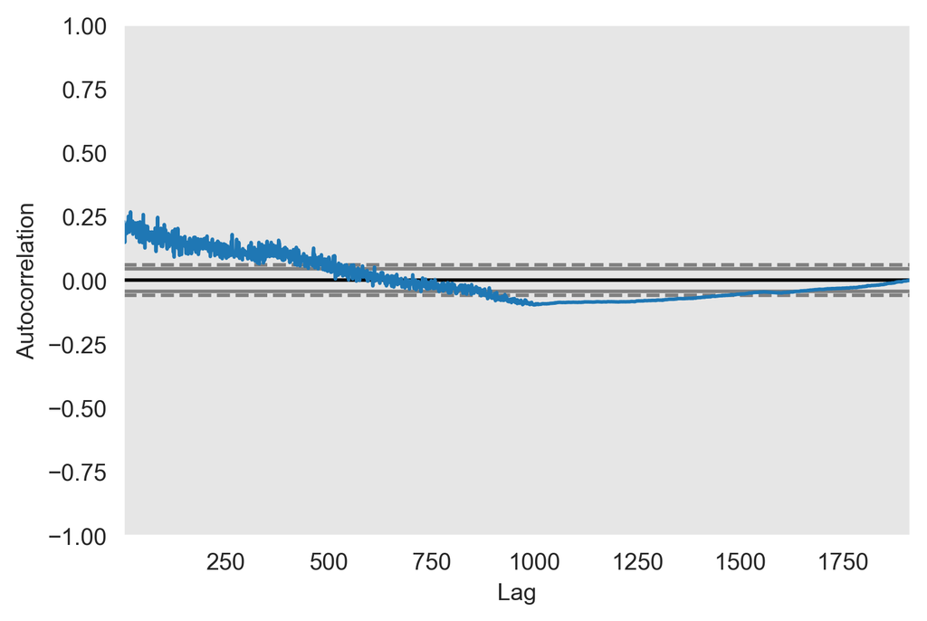

```python
pd.plotting.autocorrelation_plot(df)
```

```python
from statsmodels.tsa.arima_model import ARIMA
from sklearn.metrics import mean_squared_error
```

```python
# fit model
# order=(lag期數,差分,平均平滑)

model = ARIMA(df, order=(7,1,0))
model_fit = model.fit(disp=0)
print(model_fit.summary())
```

```
                             ARIMA Model Results
==============================================================================
Dep. Variable:             D.num_sold   No. Observations:                 1912
Model:                 ARIMA(7, 1, 0)   Log Likelihood               -1885.450
Method:                       css-mle   S.D. of innovations              0.648
Date:                Mon, 15 Jun 2020   AIC                           3788.901
Time:                        11:05:46   BIC                           3838.904
Sample:                    01-30-2011   HQIC                          3807.302
                         - 04-24-2016
====================================================================================
                       coef    std err          z      P>|z|      [0.025      0.975]
------------------------------------------------------------------------------------
const                0.0006      0.003      0.169      0.866      -0.006       0.007
ar.L1.D.num_sold    -0.8355      0.023    -36.759      0.000      -0.880      -0.791
ar.L2.D.num_sold    -0.6953      0.029    -23.833      0.000      -0.753      -0.638
ar.L3.D.num_sold    -0.5982      0.032    -18.631      0.000      -0.661      -0.535
ar.L4.D.num_sold    -0.5328      0.033    -16.285      0.000      -0.597      -0.469
ar.L5.D.num_sold    -0.3761      0.032    -11.711      0.000      -0.439      -0.313
ar.L6.D.num_sold    -0.2425      0.029     -8.304      0.000      -0.300      -0.185
ar.L7.D.num_sold    -0.1098      0.023     -4.817      0.000      -0.154      -0.065
                                    Roots
=============================================================================
                  Real          Imaginary           Modulus         Frequency
-----------------------------------------------------------------------------
AR.1            0.7820           -0.9720j            1.2475           -0.1422
AR.2            0.7820           +0.9720j            1.2475            0.1422
AR.3           -0.1000           -1.4204j            1.4239           -0.2612
AR.4           -0.1000           +1.4204j            1.4239            0.2612
AR.5           -1.0331           -0.9214j            1.3842           -0.3841
AR.6           -1.0331           +0.9214j            1.3842            0.3841
AR.7           -1.5071           -0.0000j            1.5071           -0.5000
-----------------------------------------------------------------------------
```

```python
output = model_fit.forecast()
```

```python
output[0]
```

```
array([0.92630174])
```

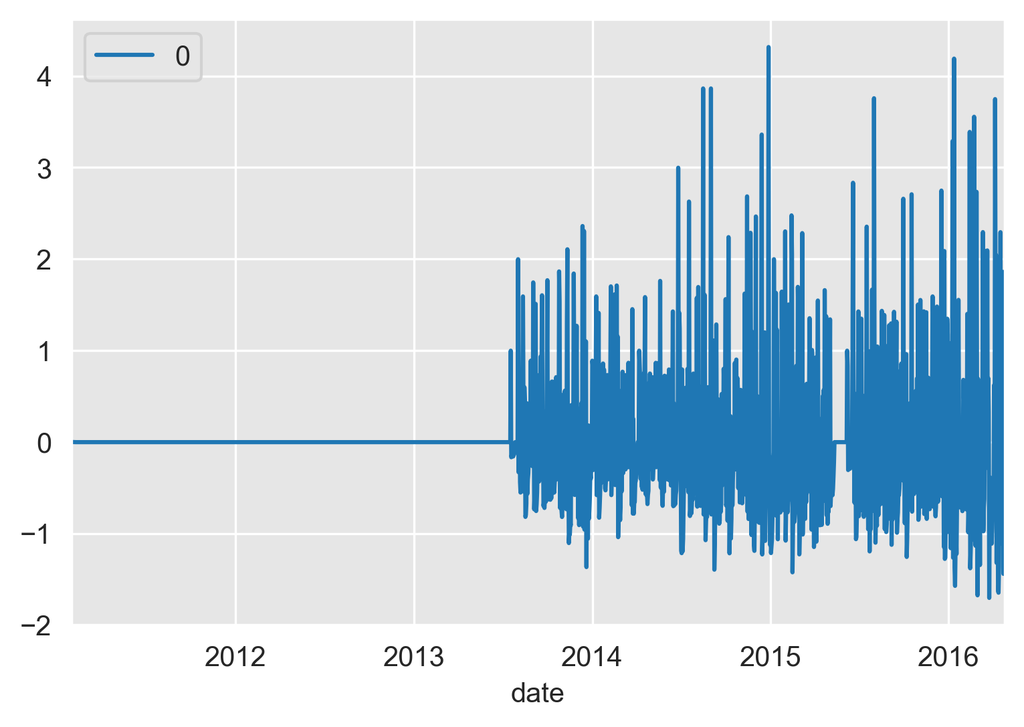

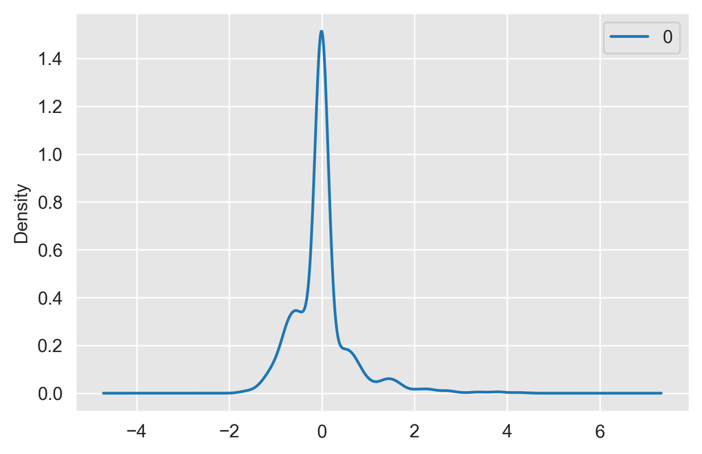

```
                 0
count  1912.000000
mean     -0.000002
std       0.648635
min      -1.705196
25%      -0.264312
50%      -0.002507
75%      -0.002507
max       4.316651
```

```python
# plot residual errors
residuals = pd.DataFrame(model_fit.resid)
residuals.plot()
plt.show()
residuals.plot(kind='kde')
plt.show()
print(residuals.describe())
```

### Start to use ARIMA model to predict

## ARIMA

```python
#每預測一次新的值Y，再將新的值Y當成真實值放入X裡面，以便預測出再下一期的Y
X = df.values
size = int(len(X) * 0.9)
train, test = X[:size], X[size:]
history = [x for x in train]
predictions = list()
for t in range(len(test)):
    model = ARIMA(history, order=(7,1,0))
    model_fit = model.fit(disp=False,  trend='nc')
    output = model_fit.forecast()
    yhat = output[0]
    predictions.append(yhat)
    obs = test[t]
    history.append(obs)
    print('predicted=%f, expected=%f' % (yhat, obs))
```

```
predicted=0.206955, expected=0.000000
predicted=0.282395, expected=3.000000
predicted=0.820416, expected=0.000000
predicted=0.630735, expected=1.000000
predicted=0.560159, expected=0.000000
predicted=0.355758, expected=0.000000
predicted=0.508344, expected=0.000000
predicted=0.536265, expected=0.000000
predicted=0.557603, expected=1.000000
predicted=0.611021, expected=1.000000
predicted=0.448676, expected=1.000000
predicted=0.499388, expected=0.000000
predicted=0.300044, expected=1.000000
predicted=0.474007, expected=0.000000
predicted=0.494480, expected=2.000000
predicted=0.863593, expected=0.000000
predicted=0.743544, expected=0.000000
predicted=0.560737, expected=0.000000
predicted=0.398562, expected=0.000000
predicted=0.414752, expected=2.000000
predicted=0.735104, expected=0.000000
predicted=0.564326, expected=0.000000
predicted=0.374033, expected=0.000000
predicted=0.147540, expected=0.000000
predicted=0.287118, expected=1.000000
predicted=0.467474, expected=1.000000
predicted=0.588879, expected=2.000000
predicted=0.749647, expected=0.000000
predicted=0.436630, expected=0.000000
predicted=0.395219, expected=0.000000
predicted=0.440036, expected=0.000000
predicted=0.589210, expected=2.000000
predicted=0.879488, expected=0.000000
predicted=0.661995, expected=0.000000
predicted=0.355391, expected=1.000000
predicted=0.306289, expected=1.000000
predicted=0.600741, expected=1.000000
predicted=0.691163, expected=1.000000
predicted=0.755379, expected=0.000000
predicted=0.627892, expected=0.000000
```

[output cut: 137 more lines]

```
predicted=1.300193, expected=2.000000
predicted=1.636380, expected=0.000000
predicted=1.650494, expected=0.000000
predicted=1.411011, expected=0.000000
predicted=0.912095, expected=1.000000
predicted=0.940101, expected=1.000000
predicted=0.702080, expected=3.000000
predicted=1.126191, expected=0.000000
predicted=0.805182, expected=1.000000
predicted=0.669998, expected=1.000000
predicted=0.792497, expected=1.000000
predicted=1.117559, expected=3.000000
predicted=1.453508, expected=0.000000
predicted=1.250045, expected=1.000000
predicted=1.142859, expected=1.000000
```

```python
predictions
```

```
[array([0.20695536]),
 array([0.28239454]),
 array([0.82041629]),
 array([0.63073484]),
 array([0.56015923]),
 array([0.35575814]),
 array([0.50834447]),
 array([0.5362652]),
 array([0.55760305]),
 array([0.61102149]),
 array([0.44867626]),
 array([0.49938839]),
 array([0.30004422]),
 array([0.4740068]),
 array([0.49447964]),
 array([0.8635927]),
 array([0.74354366]),
 array([0.5607372]),
 array([0.39856207]),
 array([0.41475184]),
 array([0.73510352]),
 array([0.56432593]),
 array([0.37403272]),
 array([0.14753991]),
 array([0.28711843]),
 array([0.46747363]),
 array([0.5888787]),
 array([0.74964738]),
 array([0.43662981]),
 array([0.39521866]),
 array([0.44003597]),
 array([0.58920973]),
 array([0.87948807]),
 array([0.66199543]),
 array([0.35539091]),
 array([0.30628908]),
 array([0.6007412]),
 array([0.69116331]),
 array([0.75537913]),
 array([0.62789162]),
```

[output cut: 137 more lines]

```
 array([1.30019316]),
 array([1.63638006]),
 array([1.65049373]),
 array([1.41101061]),
 array([0.91209464]),
 array([0.94010107]),
 array([0.70208021]),
 array([1.1261914]),
 array([0.80518169]),
 array([0.66999752]),
 array([0.79249716]),
 array([1.1175586]),
 array([1.45350766]),
 array([1.25004502]),
 array([1.14285893])]
```

```python
len(predictions)
```

```
192
```

```python
error = np.sqrt(mean_squared_error(test, predictions))
print('Test RMSE: %.3f' % error)
```

```
Test RMSE: 1.120
```

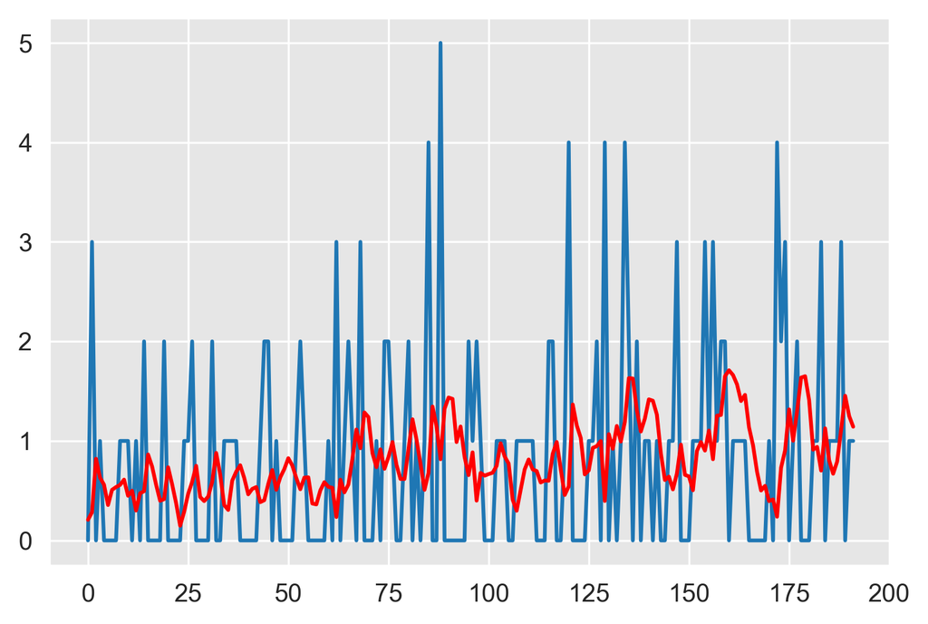

```python
# plot
plt.plot(test)
plt.plot(predictions, color='red')
plt.show()
```

可以看到使用ARIMA模型的話，會使得在預測未來銷售額，將前一天的銷售額權重放得太重

```python
import numpy as np
import pandas as pd
x_train = pd.read_csv(r'C:\Users\fish19\x_train_start')
y_train = pd.read_csv(r'C:\Users\fish19\y_train')
```

```python
x_train.head()
```

|  | Unnamed: 0 | item_id | dept_id | cat_id | store_id | state_id | date | wm_yr_wk | weekday | month | year | snap | sell_price |
| --- | --- | --- | --- | --- | --- | --- | --- | --- | --- | --- | --- | --- | --- |
| 0 | 0 | _001 | HOBBIES_1 | HOBBIES | CA_1 | CA | 2011-01-29 | 11101 | Saturday | 1 | 2011 | 0 | 9.58 |
| 1 | 1 | _001 | HOBBIES_1 | HOBBIES | CA_1 | CA | 2011-01-30 | 11101 | Sunday | 1 | 2011 | 0 | 9.58 |
| 2 | 2 | _001 | HOBBIES_1 | HOBBIES | CA_1 | CA | 2011-01-31 | 11101 | Monday | 1 | 2011 | 0 | 9.58 |
| 3 | 3 | _001 | HOBBIES_1 | HOBBIES | CA_1 | CA | 2011-02-01 | 11101 | Tuesday | 2 | 2011 | 1 | 9.58 |
| 4 | 4 | _001 | HOBBIES_1 | HOBBIES | CA_1 | CA | 2011-02-02 | 11101 | Wednesday | 2 | 2011 | 1 | 9.58 |

```python
x_train.shape
```

```
(58327370, 13)
```

```python
x_train.columns
```

```
Index(['Unnamed: 0', 'item_id', 'dept_id', 'cat_id', 'store_id', 'state_id',
       'date', 'wm_yr_wk', 'weekday', 'month', 'year', 'snap', 'sell_price'],
      dtype='object')
```

移除不需要的欄位

```python
x_train = x_train.drop(['Unnamed: 0','item_id','date','wm_yr_wk'], axis = 1)
```

```python
x_train.shape
```

```
(58327370, 9)
```

將年月從數字轉為字串

```python
x_train['month'] = x_train['month'].apply(str)
x_train['year'] = x_train['year'].apply(str)
```

```python
# one hot encoding
x_train = pd.get_dummies(x_train)
```

```python
#standardization
x_train['sell_price'] = (x_train['sell_price'] - np.mean(x_train['sell_price'])) / np.std(x_train['sell_price'])
```

```python
x_train.columns
```

```
Index(['snap', 'sell_price', 'dept_id_FOODS_1', 'dept_id_FOODS_2',
       'dept_id_FOODS_3', 'dept_id_HOBBIES_1', 'dept_id_HOBBIES_2',
       'dept_id_HOUSEHOLD_1', 'dept_id_HOUSEHOLD_2', 'cat_id_FOODS',
       'cat_id_HOBBIES', 'cat_id_HOUSEHOLD', 'store_id_CA_1', 'store_id_CA_2',
       'store_id_CA_3', 'store_id_CA_4', 'store_id_TX_1', 'store_id_TX_2',
       'store_id_TX_3', 'store_id_WI_1', 'store_id_WI_2', 'store_id_WI_3',
       'state_id_CA', 'state_id_TX', 'state_id_WI', 'weekday_Friday',
       'weekday_Monday', 'weekday_Saturday', 'weekday_Sunday',
       'weekday_Thursday', 'weekday_Tuesday', 'weekday_Wednesday', 'month_1',
       'month_10', 'month_11', 'month_12', 'month_2', 'month_3', 'month_4',
       'month_5', 'month_6', 'month_7', 'month_8', 'month_9', 'year_2011',
       'year_2012', 'year_2013', 'year_2014', 'year_2015', 'year_2016'],
      dtype='object')
```

將test 資料做跟train 一樣的處理

```python
x_test = pd.read_csv(r'C:\Users\fish19\x_test_start')
y_test = pd.read_csv(r'C:\Users\fish19\y_test')
```

```python
x_test.head()
```

|  | Unnamed: 0 | id | item_id | dept_id | cat_id | store_id | state_id | d | num_sold | date | wm_yr_wk | weekday | month | year | snap | sell_price |
| --- | --- | --- | --- | --- | --- | --- | --- | --- | --- | --- | --- | --- | --- | --- | --- | --- |
| 0 | 0 | HOBBIES_1_001_CA_1_evaluation | HOBBIES_1_001 | HOBBIES_1 | HOBBIES | CA_1 | CA | d_1914 | 0 | 2016-05-23 | 11617 | Monday | 5 | 2016 | 0 | 8.38 |
| 1 | 1 | HOBBIES_1_001_CA_1_evaluation | HOBBIES_1_001 | HOBBIES_1 | HOBBIES | CA_1 | CA | d_1915 | 0 | 2016-05-24 | 11617 | Tuesday | 5 | 2016 | 0 | 8.38 |
| 2 | 2 | HOBBIES_1_001_CA_1_evaluation | HOBBIES_1_001 | HOBBIES_1 | HOBBIES | CA_1 | CA | d_1916 | 0 | 2016-05-25 | 11617 | Wednesday | 5 | 2016 | 0 | 8.38 |
| 3 | 3 | HOBBIES_1_001_CA_1_evaluation | HOBBIES_1_001 | HOBBIES_1 | HOBBIES | CA_1 | CA | d_1917 | 2 | 2016-05-26 | 11617 | Thursday | 5 | 2016 | 0 | 8.38 |
| 4 | 4 | HOBBIES_1_001_CA_1_evaluation | HOBBIES_1_001 | HOBBIES_1 | HOBBIES | CA_1 | CA | d_1918 | 0 | 2016-05-27 | 11617 | Friday | 5 | 2016 | 0 | 8.38 |

```python
x_test.columns
```

```
Index(['Unnamed: 0', 'id', 'item_id', 'dept_id', 'cat_id', 'store_id',
       'state_id', 'd', 'num_sold', 'date', 'wm_yr_wk', 'weekday', 'month',
       'year', 'snap', 'sell_price'],
      dtype='object')
```

```python
#drop columns
x_test = x_test.drop(['Unnamed: 0', 'id', 'item_id', 'd', 'num_sold', 'date','wm_yr_wk'], axis = 1)
```

```python
#transform year and month to string
x_test['month'] = x_test['month'].apply(str)
x_test['year'] = x_test['year'].apply(str)
```

```python
#one hot encoding
x_test = pd.get_dummies(x_test)
```

```python
#standardization
x_test['sell_price'] = (x_test['sell_price'] - np.mean(x_test['sell_price'])) / np.std(x_test['sell_price'])
```

```python
x_test.shape
```

```
(853720, 35)
```

```python
x_test.columns
```

```
Index(['snap', 'sell_price', 'dept_id_FOODS_1', 'dept_id_FOODS_2',
       'dept_id_FOODS_3', 'dept_id_HOBBIES_1', 'dept_id_HOBBIES_2',
       'dept_id_HOUSEHOLD_1', 'dept_id_HOUSEHOLD_2', 'cat_id_FOODS',
       'cat_id_HOBBIES', 'cat_id_HOUSEHOLD', 'store_id_CA_1', 'store_id_CA_2',
       'store_id_CA_3', 'store_id_CA_4', 'store_id_TX_1', 'store_id_TX_2',
       'store_id_TX_3', 'store_id_WI_1', 'store_id_WI_2', 'store_id_WI_3',
       'state_id_CA', 'state_id_TX', 'state_id_WI', 'weekday_Friday',
       'weekday_Monday', 'weekday_Saturday', 'weekday_Sunday',
       'weekday_Thursday', 'weekday_Tuesday', 'weekday_Wednesday', 'month_5',
       'month_6', 'year_2016'],
      dtype='object')
```

由於test 的欄位比train少，補足相同的欄位

```python
#store column of month 5 and month 6
x_test_rest = x_test[['month_5', 'month_6']]
```

```python
#store column of 2016
x_test_last = x_test[['year_2016']]
```

```python
#drop columns
x_test = x_test.drop(['month_5','month_6', 'year_2016'], axis = 1)
```

```python
# add columns
x_test['month_1'] = 0
x_test['month_2'] = 0
x_test['month_3'] = 0
x_test['month_4'] = 0
```

```python
x_test = pd.concat([x_test,x_test_rest], axis = 1)
```

```python
x_test['month_7'] = 0
x_test['month_8'] = 0
x_test['month_9'] = 0
x_test['month_10'] = 0
x_test['month_11'] = 0
x_test['month_12'] = 0
x_test['year_2011'] = 0
x_test['year_2012'] = 0
x_test['year_2013'] = 0
x_test['year_2014'] = 0
x_test['year_2015'] = 0
x_test = pd.concat([x_test,x_test_last], axis = 1)
```

```python
x_test.head()
```

|  | snap | sell_price | dept_id_FOODS_1 | dept_id_FOODS_2 | dept_id_FOODS_3 | dept_id_HOBBIES_1 | dept_id_HOBBIES_2 | dept_id_HOUSEHOLD_1 | dept_id_HOUSEHOLD_2 | cat_id_FOODS | ... | month_9 | month_10 | month_11 | month_12 | year_2011 | year_2012 | year_2013 | year_2014 | year_2015 | year_2016 |
| --- | --- | --- | --- | --- | --- | --- | --- | --- | --- | --- | --- | --- | --- | --- | --- | --- | --- | --- | --- | --- | --- |
| 0 | 0 | 1.103713 | 0 | 0 | 0 | 1 | 0 | 0 | 0 | 0 | ... | 0 | 0 | 0 | 0 | 0 | 0 | 0 | 0 | 0 | 1 |
| 1 | 0 | 1.103713 | 0 | 0 | 0 | 1 | 0 | 0 | 0 | 0 | ... | 0 | 0 | 0 | 0 | 0 | 0 | 0 | 0 | 0 | 1 |
| 2 | 0 | 1.103713 | 0 | 0 | 0 | 1 | 0 | 0 | 0 | 0 | ... | 0 | 0 | 0 | 0 | 0 | 0 | 0 | 0 | 0 | 1 |
| 3 | 0 | 1.103713 | 0 | 0 | 0 | 1 | 0 | 0 | 0 | 0 | ... | 0 | 0 | 0 | 0 | 0 | 0 | 0 | 0 | 0 | 1 |
| 4 | 0 | 1.103713 | 0 | 0 | 0 | 1 | 0 | 0 | 0 | 0 | ... | 0 | 0 | 0 | 0 | 0 | 0 | 0 | 0 | 0 | 1 |

5 rows × 50 columns

```python
x_train.head()
```

|  | snap | sell_price | dept_id_FOODS_1 | dept_id_FOODS_2 | dept_id_FOODS_3 | dept_id_HOBBIES_1 | dept_id_HOBBIES_2 | dept_id_HOUSEHOLD_1 | dept_id_HOUSEHOLD_2 | cat_id_FOODS | ... | month_6 | month_7 | month_8 | month_9 | year_2011 | year_2012 | year_2013 | year_2014 | year_2015 | year_2016 |
| --- | --- | --- | --- | --- | --- | --- | --- | --- | --- | --- | --- | --- | --- | --- | --- | --- | --- | --- | --- | --- | --- |
| 0 | 0 | 1.456259 | 0 | 0 | 0 | 1 | 0 | 0 | 0 | 0 | ... | 0 | 0 | 0 | 0 | 1 | 0 | 0 | 0 | 0 | 0 |
| 1 | 0 | 1.456259 | 0 | 0 | 0 | 1 | 0 | 0 | 0 | 0 | ... | 0 | 0 | 0 | 0 | 1 | 0 | 0 | 0 | 0 | 0 |
| 2 | 0 | 1.456259 | 0 | 0 | 0 | 1 | 0 | 0 | 0 | 0 | ... | 0 | 0 | 0 | 0 | 1 | 0 | 0 | 0 | 0 | 0 |
| 3 | 1 | 1.456259 | 0 | 0 | 0 | 1 | 0 | 0 | 0 | 0 | ... | 0 | 0 | 0 | 0 | 1 | 0 | 0 | 0 | 0 | 0 |
| 4 | 1 | 1.456259 | 0 | 0 | 0 | 1 | 0 | 0 | 0 | 0 | ... | 0 | 0 | 0 | 0 | 1 | 0 | 0 | 0 | 0 | 0 |

5 rows × 50 columns

處理y 多餘的標示欄位

```python
y_train = y_train.drop('Unnamed: 0', axis = 1 )
```

```python
y_test = y_test.drop('Unnamed: 0', axis = 1 )
```

```python
x_train.shape
```

```
(58327370, 50)
```

```python
y_train.shape
```

```
(58327370, 1)
```

```python
x_test.shape
```

```
(853720, 50)
```

```python
y_test.shape
```

```
(853720, 1)
```

xgboost model

```python
!pip install xgboost
```

```python
import seaborn as sns
import matplotlib.pyplot as plt
import xgboost as xgb
from xgboost import plot_importance, plot_tree
from sklearn.metrics import mean_squared_error, mean_absolute_error
```

取第一項商品做測試，先做validation取1913天其中前1721天訓練，剩下192天做驗證

```python
#validation
train_days = 1721
x = x_train.iloc[:train_days].values
y = y_train.iloc[:train_days].values
test_days = 192
xtest = x_train.iloc[train_days:train_days + test_days].values
ytest = y_train.iloc[train_days:train_days + test_days].values
reg = xgb.XGBRegressor(n_estimators=10000)
reg.fit(x,y)
predictions_1 = reg.predict(xtest)
```

```python
predictions_1.reshape((192,1))
```

```
array([[ 4.04847145e-01],
       [ 7.81655312e-03],
       [ 9.83543634e-01],
       [ 9.93816018e-01],
       [ 2.22872198e-02],
       [ 5.03113866e-03],
       [-5.14209270e-04],
       [ 4.04847145e-01],
       [ 7.81655312e-03],
       [ 9.83543634e-01],
       [ 9.93816018e-01],
       [ 2.22872198e-02],
       [ 5.03113866e-03],
       [-5.14209270e-04],
       [ 4.04847145e-01],
       [ 7.81655312e-03],
       [ 1.26226163e+00],
       [ 5.13263524e-01],
       [ 6.04845881e-01],
       [ 3.14810216e-01],
       [ 5.23113012e-01],
       [ 4.68011558e-01],
       [ 1.53193069e+00],
       [ 1.26226163e+00],
       [ 5.13263524e-01],
       [ 6.04845881e-01],
       [ 5.12667477e-01],
       [ 5.28460085e-01],
       [ 9.07972574e-01],
       [ 9.79144037e-01],
       [ 7.42478490e-01],
       [ 1.20833158e+00],
       [ 3.52355331e-01],
       [ 5.12667477e-01],
       [ 5.28460085e-01],
       [ 9.07972574e-01],
       [ 9.79144037e-01],
       [ 7.42478490e-01],
       [ 1.20833158e+00],
       [ 3.52355331e-01],
```

[output cut: 137 more lines]

```
       [ 1.02815330e-02],
       [ 5.68478167e-01],
       [ 2.25416452e-01],
       [ 3.13146561e-01],
       [ 3.65294397e-01],
       [ 3.08451116e-01],
       [ 8.96049500e-01],
       [ 1.05891585e-01],
       [ 5.68478167e-01],
       [ 2.25416452e-01],
       [ 3.13146561e-01],
       [ 3.65294397e-01],
       [ 3.08451116e-01],
       [ 8.96049500e-01],
       [ 1.05891585e-01]], dtype=float32)
```

```python
def RMSE(y_real, y_hat):
    RMSE = 0
    for i in range (len(y_real)):
        RMSE += (y_real[i] - y_hat[i])**2
    RMSE = (RMSE / len(y_real)) ** 0.5
    return RMSE
```

```python
RMSE(predictions_1, ytest)
```

```
array([1.1348348])
```

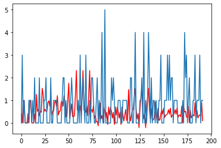

```python
plt.plot(predictions_1, color = 'red')
plt.plot(ytest)
```

```python
#evaluation
train = 1913
x_t = x_train.iloc[:train].values
y_t = y_train.iloc[:train].values
test = 28
x_eval = x_test.iloc[train:train + test].values
y_eval = y_test.iloc[train:train + test].values
reg.fit(x_t,y_t)
predictions_2 = reg.predict(x_eval)
```

```python
predictions_2.reshape((28,1))
```

```
array([[ 4.9986911e-01],
       [ 9.9984199e-01],
       [ 1.0045100e+00],
       [-1.1335015e-03],
       [ 9.9573773e-01],
       [ 1.8934846e-02],
       [ 9.9861801e-01],
       [ 4.9986911e-01],
       [ 9.9984199e-01],
       [ 1.0045100e+00],
       [ 6.6764188e-01],
       [ 1.3335721e+00],
       [ 6.6505086e-01],
       [ 9.9975812e-01],
       [ 1.0012171e+00],
       [ 3.3698702e-01],
       [ 2.3288980e+00],
       [ 6.6764188e-01],
       [ 1.3335721e+00],
       [ 1.3326385e+00],
       [-5.3155422e-04],
       [ 5.0163823e-01],
       [ 3.3771554e-01],
       [ 1.0017914e+00],
       [ 3.3297536e+00],
       [ 6.6378713e-01],
       [ 1.3326385e+00],
       [-5.3155422e-04]], dtype=float32)
```

```python
RMSE(predictions_2, y_eval)
```

```
array([1.16121088])
```

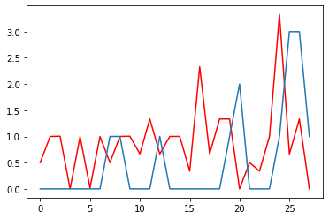

```python
plt.plot(predictions_2, color = 'red')
plt.plot(y_eval)
```

### LSTM 模型

除了前面利用ARIMA, XGBOOST等方法，我們也想利用深度學習的方式去嘗試預測，而由於資料是時間序列，因此我們採用LSTM作為模型。

```python
import numpy as np
import pandas as pd
import matplotlib.pyplot as plt
import seaborn as sns
from google.colab import files
from google.colab import drive
from sklearn.model_selection import train_test_split
drive.mount('/content/drive')
```

```
Go to this URL in a browser: https://accounts.google.com/o/oauth2/auth?client_id=947318989803-6bn6qk8qdgf4n4g3pfee6491hc0brc4i.apps.googleusercontent.com&redirect_uri=urn%3aietf%3awg%3aoauth%3a2.0%3aoob&response_type=code&scope=email%20https%3a%2f%2fwww.googleapis.com%2fauth%2fdocs.test%20https%3a%2…

Enter your authorization code:
··········
```

採用 HOBBIES_1_001_CA_1，也就是HOBBIES_1類別中第一個商品在California州中的第一間商店，作為部分的資料。與ARIMA, XGBOOST使用相同的商品資料，以利於最終比較結果，進而選擇最終使用的模型。

```python
CA_data = pd.read_csv("/content/drive/My Drive/Colab Notebooks/SL Data/data_by_state/CA_df.csv",\
                      dtype = {'item_id':'str', 'dept_id':'str', 'store_id':'str', 'month':'str', 'year':'str', 'snap':'str'})
CA_data.shape
```

```
(23330948, 12)
```

```python
CA_data.head()
```

|  | item_id | dept_id | cat_id | store_id | state_id | num_sold | weekday | month | year | snap | sell_price | d_num |
| --- | --- | --- | --- | --- | --- | --- | --- | --- | --- | --- | --- | --- |
| 0 | 001 | 1 | HOBBIES | 1 | CA | 0 | Saturday | 1 | 2011 | 0 | 9.58 | 1 |
| 1 | 001 | 1 | HOBBIES | 1 | CA | 0 | Sunday | 1 | 2011 | 0 | 9.58 | 2 |
| 2 | 001 | 1 | HOBBIES | 1 | CA | 0 | Monday | 1 | 2011 | 0 | 9.58 | 3 |
| 3 | 001 | 1 | HOBBIES | 1 | CA | 0 | Tuesday | 2 | 2011 | 1 | 9.58 | 4 |
| 4 | 001 | 1 | HOBBIES | 1 | CA | 0 | Wednesday | 2 | 2011 | 1 | 9.58 | 5 |

```python
# Data preprocessing
# Drop year, create id_column
CA_data.drop('year', axis=1, inplace = True)
CA_data['id'] = CA_data['cat_id'] + '_' + CA_data['dept_id'] + '_' + CA_data['item_id'] + '_' + CA_data['state_id'] + '_' + CA_data['store_id']
```

```python
# Use store_1 in CA and HOBBIES_1_001
CA_1_data = CA_data[(CA_data['store_id']=='1') & (CA_data['cat_id']=="HOBBIES") & (CA_data['dept_id'] == '1') & (CA_data['item_id'] == '001')]
```

```python
# item_1 = CA_1_data
item_1 = CA_1_data.reset_index(drop = True)
item_1.shape
```

```
(1913, 12)
```

#### ONE_HOT_ENCODING

我們將類別資料轉換為one-hot-encoding的形式，類別資料包含商品id, 商品dept_id, 商品cat_id, weekday以及snap。

```python
item_1_dummy = pd.get_dummies(item_1,columns = ['item_id', 'dept_id', 'cat_id', 'weekday', 'snap'], drop_first=True)
item_1_dummy.head(2)
```

|  | store_id | state_id | num_sold | month | sell_price | d_num | id | weekday_Monday | weekday_Saturday | weekday_Sunday | weekday_Thursday | weekday_Tuesday | weekday_Wednesday | snap_1 |
| --- | --- | --- | --- | --- | --- | --- | --- | --- | --- | --- | --- | --- | --- | --- |
| 0 | 1 | CA | 0 | 1 | 9.58 | 1 | HOBBIES_1_001_CA_1 | 0 | 1 | 0 | 0 | 0 | 0 | 0 |
| 1 | 1 | CA | 0 | 1 | 9.58 | 2 | HOBBIES_1_001_CA_1 | 0 | 0 | 1 | 0 | 0 | 0 | 0 |

```python
# 取約10%的資料作為模型的validation data
train_1_data, val_1_data = item_1_dummy[item_1_dummy['d_num'] < 1723], item_1_dummy[item_1_dummy['d_num'] >= 1723]
```

#### Create train test dataframes

```python
def create_xy_data(df):
  x_train_id, y_train = df['id'],df['num_sold']
  df = df.drop(['id','d_num','state_id','num_sold','store_id'],axis=1)
  return df, y_train, x_train_id
```

```python
x_train, y_train, x_train_id = create_xy_data(train_1_data)
x_val, y_val, x_val_id = create_xy_data(val_1_data)
```

```python
x_train.head()
```

|  | month | sell_price | weekday_Monday | weekday_Saturday | weekday_Sunday | weekday_Thursday | weekday_Tuesday | weekday_Wednesday | snap_1 |
| --- | --- | --- | --- | --- | --- | --- | --- | --- | --- |
| 0 | 1 | 9.58 | 0 | 1 | 0 | 0 | 0 | 0 | 0 |
| 1 | 1 | 9.58 | 0 | 0 | 1 | 0 | 0 | 0 | 0 |
| 2 | 1 | 9.58 | 1 | 0 | 0 | 0 | 0 | 0 | 0 |
| 3 | 2 | 9.58 | 0 | 0 | 0 | 0 | 1 | 0 | 1 |
| 4 | 2 | 9.58 | 0 | 0 | 0 | 0 | 0 | 1 | 1 |

```python
y_train.head()
```

```
0    0
1    0
2    0
3    0
4    0
Name: num_sold, dtype: int64
```

#### 標準化連續變數

標準化連續變數可以減少因數值大小造成weights的偏移，而我們的連續變數只有price(商品價格)一項，因此我們只需標準化price這項特徵即可。

```python
from sklearn.preprocessing import StandardScaler
```

```python
scaler_x = StandardScaler()
x_train['sell_price'] = scaler_x.fit_transform(np.array(x_train['sell_price']).reshape(-1,1))
x_val['sell_price'] = scaler_x.transform(np.array(x_val['sell_price']).reshape(-1,1))
```

```python
x_train.head(2)
```

|  | month | sell_price | weekday_Monday | weekday_Saturday | weekday_Sunday | weekday_Thursday | weekday_Tuesday | weekday_Wednesday | snap_1 |
| --- | --- | --- | --- | --- | --- | --- | --- | --- | --- |
| 0 | 1 | 0.94462 | 0 | 1 | 0 | 0 | 0 | 0 | 0 |
| 1 | 1 | 0.94462 | 0 | 0 | 1 | 0 | 0 | 0 | 0 |

```python
print(x_train.shape, x_val.shape)
```

```
(1722, 9) (191, 9)
```

### Convert Data Dimension

LSTM是適合時間序列的模型，也因為這個特性，input data 可以是三維的資料，也就是除了平常的(資料筆數, 特徵數量)以外，還可以加上時間。

由於這次的目標是預測未來28天，因此我們很初步的將往回看的資料設定為前28天，也就是說每個資料點在做判斷時，模型會同時考量前28天的資料。加入時間後，特徵dataframe的維度會變為(資料筆數, 往回看的天數, 特徵數量)的三維資料。

```python
LOOKBACK_MAX = 28
```

```python
x_train_time = []
for i in range(LOOKBACK_MAX, x_train.shape[0]):
  x_train_time.append(x_train.iloc[i - LOOKBACK_MAX:i].values.tolist())
x_train_time = np.array(x_train_time)

x_val_time = []
for i in range(LOOKBACK_MAX, x_val.shape[0]):
  x_val_time.append(x_val.iloc[i-LOOKBACK_MAX:i].values.tolist())
x_val_time = np.array(x_val_time)

y_train = y_train.values
y_val = y_val.values
y_train_time = y_train[LOOKBACK_MAX:]
y_val_time = y_val[LOOKBACK_MAX:]
print(x_train_time.shape, y_train_time.shape, x_val_time.shape, y_val_time.shape)
```

```
(1694, 28, 9) (1694,) (163, 28, 9) (163,)
```

#### Build Model

這邊利用keras作為架構模型的工具，模型則為一層LSTM + 三層Dense layer，而最後一層Dense layer 的activation function 我們將其設為 linear，因為我們要預測的是回歸的問題

```python
import keras
from keras import Sequential
from keras import layers
```

```python
def build_model(shape):
  model = Sequential()
  model.add(layers.LSTM(50, input_shape=(shape[1], shape[2]), return_sequences=False))

  model.add(layers.Dense(32, activation='relu'))
  model.add(layers.Dense(16, activation='relu'))
  model.add(layers.Dense(1, activation = 'linear'))

  model.compile(
      loss= keras.losses.MeanSquaredError(),
      optimizer='adam',
  )

  return model
```

```python
model = build_model(x_train_time.shape)
history = model.fit(x = x_train_time,
                    y = y_train_time,
                    epochs=10,
                    validation_data=(x_val_time, y_val_time),
                    shuffle=True,
                    batch_size=128)
```

```
Train on 1694 samples, validate on 163 samples
```

```python
model.summary()
```

```
Model: "sequential_11"
_________________________________________________________________
Layer (type)                 Output Shape              Param #
=================================================================
lstm_13 (LSTM)               (None, 50)                12000
_________________________________________________________________
dense_26 (Dense)             (None, 32)                1632
_________________________________________________________________
dense_27 (Dense)             (None, 16)                528
_________________________________________________________________
dense_28 (Dense)             (None, 1)                 17
=================================================================
Total params: 14,177
Trainable params: 14,177
Non-trainable params: 0
_________________________________________________________________
```

#### Validation Prediction Results

這邊我們用前面切好的validation data 來做驗證，看RMSE 以及預測及真實圖形看起來會是什麼樣子

```python
y_pre_val = model.predict(x_val_time)
y_pre_val = y_pre_val.reshape(-1,)
```

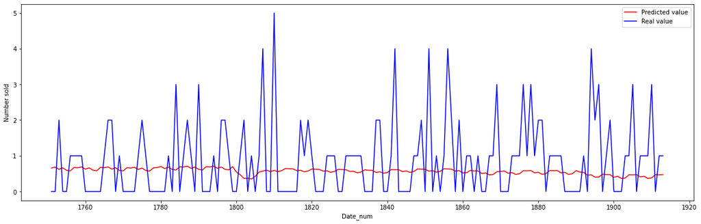

```python
plt_x = np.arange(1914-len(y_val_time), 1914, 1)
plt_y1 = y_pre_val
plt_y2 = y_val_time
plt.figure(figsize=(20,6))
plt.plot(plt_x, plt_y1, color='r', label = "Predicted value")
plt.plot(plt_x, plt_y2, color = 'b', label = "Real value")
plt.legend()
plt.xlabel("Date_num")
plt.ylabel("Number sold")
plt.show()
plt.close()
```

```python
from sklearn.metrics import mean_squared_error
RMSE = np.sqrt(mean_squared_error(y_pre_val, y_val_time))
print("RMSE = ", RMSE)
```

```
RMSE =  1.1165011935545595
```

### Another DL Model

```python
def build_CNN(shape):
  model = Sequential()
  model.add(layers.Conv1D(32, kernel_size=4,input_shape = (shape[1], shape[2],),activation="relu"))
  model.add(layers.MaxPooling1D())
  model.add(layers.Conv1D(32, kernel_size=4,activation="relu"))
  model.add(layers.MaxPooling1D())
  model.add(layers.Flatten())
  model.add(layers.Dense(32, activation='relu'))
  model.add(layers.Dense(32, activation='relu'))
  model.add(layers.Dense(1, activation='linear'))

  opt = keras.optimizers.Adam()
  model.compile(
      loss='MSE',
      optimizer=opt
  )

  return model
```

```python
CNN_model = build_CNN(x_train_time.shape)
history = CNN_model.fit(x = x_train_time,
                        y = y_train_time,
                        epochs=10,
                        validation_data=(x_val_time, y_val_time),
                        shuffle=True,
                        batch_size = 128)
```

```
Train on 1694 samples, validate on 163 samples
```

```python
y_pre_val = CNN_model.predict(x_val_time)
y_pre_val = y_pre_val.reshape(-1,)
```

```python
from sklearn.metrics import mean_squared_error
RMSE = np.sqrt(mean_squared_error(y_pre_val, y_val_time))
print("RMSE = ", RMSE)
```

```
RMSE =  1.1066745379814134
```

### LSTM for all data

這個notebook是我們做訓練及預測的code，由於我們有先把資料切成三個檔案，分別是照商品類別HOBBIES、FOODS、HOUSEHOLD切的，因此，要將此檔案執行三次，再將輸出的預測結果合併，即為最終的預測檔案

```python
import numpy as np
import pandas as pd
import matplotlib.pyplot as plt
import seaborn as sns
from google.colab import files
from google.colab import drive
from sklearn.model_selection import train_test_split
from sklearn.preprocessing import StandardScaler
from sklearn.metrics import mean_squared_error
from keras.callbacks import Callback, ModelCheckpoint
```

```python
drive.mount('/content/drive')
```

```
Go to this URL in a browser: https://accounts.google.com/o/oauth2/auth?client_id=947318989803-6bn6qk8qdgf4n4g3pfee6491hc0brc4i.apps.googleusercontent.com&redirect_uri=urn%3aietf%3awg%3aoauth%3a2.0%3aoob&response_type=code&scope=email%20https%3a%2f%2fwww.googleapis.com%2fauth%2fdocs.test%20https%3a%2…

Enter your authorization code:
··········
```

```python
HH_data = pd.read_csv("/content/drive/My Drive/統計學習初論/Editted data/HOUSEHOLD_df.csv",\
                      dtype = {'item_id':'str', 'dept_id':'str', 'store_id':'str', 'month':'str', 'year':'str', 'snap':'str'})
```

```python
test_1_data = pd.read_csv("/content/drive/My Drive/統計學習初論/Editted data/test_1_HOUSEHOLD_df.csv",\
                      dtype = {'item_id':'str', 'dept_id':'str', 'store_id':'str', 'month':'str', 'year':'str', 'snap':'str'})
```

```python
test_2_data = pd.read_csv("/content/drive/My Drive/統計學習初論/Editted data/test_2_HOUSEHOLD_df.csv",\
                      dtype = {'item_id':'str', 'dept_id':'str', 'store_id':'str', 'month':'str', 'year':'str', 'snap':'str'})
```

```python
HH_data.head(2)
```

|  | item_id | dept_id | cat_id | store_id | state_id | num_sold | weekday | month | year | snap | sell_price | d_num | event_type_1_National | event_type_1_Religious | event_type_1_Sporting | dept_item |
| --- | --- | --- | --- | --- | --- | --- | --- | --- | --- | --- | --- | --- | --- | --- | --- | --- |
| 0 | 001 | 1 | HOUSEHOLD | 1 | CA | 3 | Saturday | 1 | 2011 | 0 | 6.32 | 1 | 0 | 0 | 0 | 1_001 |
| 1 | 001 | 1 | HOUSEHOLD | 1 | CA | 0 | Sunday | 1 | 2011 | 0 | 6.32 | 2 | 0 | 0 | 0 | 1_001 |

```python
test_1_data.head(2)
```

|  | item_id | dept_id | cat_id | store_id | state_id | num_sold | weekday | month | year | snap | sell_price | d_num | event_type_1_Religious | event_type_1_National | event_type_1_Sporting | dept_item |
| --- | --- | --- | --- | --- | --- | --- | --- | --- | --- | --- | --- | --- | --- | --- | --- | --- |
| 0 | 001 | 1 | HOUSEHOLD | 1 | CA | 1 | Monday | 4 | 2016 | 0 | 5.97 | 1914 | 0 | 0 | 0 | 1_001 |
| 1 | 001 | 1 | HOUSEHOLD | 1 | CA | 0 | Tuesday | 4 | 2016 | 0 | 5.97 | 1915 | 0 | 0 | 0 | 1_001 |

```python
test_2_data.head(2)
```

|  | item_id | dept_id | cat_id | store_id | state_id | weekday | month | year | snap | sell_price | d_num | event_type_1_Religious | event_type_1_Sporting | event_type_1_National | dept_item |
| --- | --- | --- | --- | --- | --- | --- | --- | --- | --- | --- | --- | --- | --- | --- | --- |
| 0 | 001 | 1 | HOUSEHOLD | 1 | CA | Monday | 4 | 2016 | 0 | 5.97 | 1942 | 0 | 0 | 0 | 1_001 |
| 1 | 001 | 1 | HOUSEHOLD | 1 | CA | Tuesday | 4 | 2016 | 0 | 5.97 | 1943 | 0 | 0 | 0 | 1_001 |

```python
data = HH_data
```

```python
def create_id_col(data):
  id_col = data['cat_id'] + '_' + data['dept_id'] + '_' + data['item_id'] + '_' + data['state_id'] + '_' + data['store_id']
  return id_col
```

```python
# Create id
data['id'] = create_id_col(data)
test_1_data['id'] = create_id_col(test_1_data)
test_2_data['id'] = create_id_col(test_2_data)
```

```python
data.head()
```

|  | item_id | dept_id | cat_id | store_id | state_id | num_sold | weekday | month | year | snap | sell_price | d_num | event_type_1_National | event_type_1_Religious | event_type_1_Sporting | dept_item | id |
| --- | --- | --- | --- | --- | --- | --- | --- | --- | --- | --- | --- | --- | --- | --- | --- | --- | --- |
| 0 | 001 | 1 | HOUSEHOLD | 1 | CA | 3 | Saturday | 1 | 2011 | 0 | 6.32 | 1 | 0 | 0 | 0 | 1_001 | HOUSEHOLD_1_001_CA_1 |
| 1 | 001 | 1 | HOUSEHOLD | 1 | CA | 0 | Sunday | 1 | 2011 | 0 | 6.32 | 2 | 0 | 0 | 0 | 1_001 | HOUSEHOLD_1_001_CA_1 |
| 2 | 001 | 1 | HOUSEHOLD | 1 | CA | 0 | Monday | 1 | 2011 | 0 | 6.32 | 3 | 0 | 0 | 0 | 1_001 | HOUSEHOLD_1_001_CA_1 |
| 3 | 001 | 1 | HOUSEHOLD | 1 | CA | 0 | Tuesday | 2 | 2011 | 1 | 6.32 | 4 | 0 | 0 | 0 | 1_001 | HOUSEHOLD_1_001_CA_1 |
| 4 | 001 | 1 | HOUSEHOLD | 1 | CA | 0 | Wednesday | 2 | 2011 | 1 | 6.32 | 5 | 0 | 0 | 0 | 1_001 | HOUSEHOLD_1_001_CA_1 |

```python
print(data.shape)
print(test_1_data.shape)
print(test_2_data.shape)
```

```
(15989319, 17)
(293160, 17)
(293160, 16)
```

```python
def create_xy_data(df, pre_type = ""): # for one item at once
  x_train_id = (df['id'] + "_" + pre_type).values
  idx = np.unique(x_train_id, return_index=True)[1]
  idx.sort()
  x_train_id = x_train_id[idx]
  y_train = df['num_sold'].values
  df = df.drop(['id','d_num','num_sold','item_id', 'dept_id', 'cat_id', 'dept_item','year'],axis=1)
  return df, y_train, x_train_id
```

```python
def create_x(df, pre_type=""): # for one item at once
  x_train_id = (df['id'] + "_" + pre_type).values
  idx = np.unique(x_train_id, return_index=True)[1]
  idx.sort()
  x_train_id = x_train_id[idx]
  df = df.drop(['id','d_num','item_id', 'dept_id', 'cat_id', 'dept_item','year'],axis=1)
  return df, x_train_id
```

```python
import keras
from keras import Sequential
from keras import layers
```

```python
def build_model(shape):
  model = Sequential()
  model.add(layers.LSTM(50, input_shape=(shape[1], shape[2]), return_sequences=True))
  model.add(layers.LSTM(40))
  model.add(layers.Dropout(0.5))
  model.add(layers.Dense(16, activation='relu'))
  model.add(layers.Dense(8, activation='relu'))
  model.add(layers.Dense(1, activation = 'linear'))

  model.compile(
      loss= keras.losses.MeanSquaredError(),
      optimizer='adam',
  )

  return model
```

```python
# 根據自回歸的結果，當天的銷售量與前1、7、14天的相關性較高，因此我們取這幾天做為資料回看的天數
LOOKBACK_MAX = 14
LOOKBACK_ARR = np.array([0,1,7,14])

y_val_pre_all = []
y_eval_pre_all = []
val_id_all = []
eval_id_all = []
SE_list = []      # list for mean squared error of each item

# 我們為每個商品(unique dept_item_id)建立一個model，並在預測完畢後再進入下一個商品
for dept_item_id in dept_item_ids: # one item at once
  print("-----------------------------------")
  print("Current item is ", dept_item_id)
  train_data = data[data['dept_item'] == dept_item_id].reset_index(drop=True)
  val_data = test_1_data[test_1_data['dept_item'] == dept_item_id].reset_index(drop=True)
  eval_data = test_2_data[test_2_data['dept_item'] == dept_item_id].reset_index(drop=True)

  # 由於要取前1,7,14天時，若使用不同商店的資料是不合理的，因此這邊先將商店名儲存，以利之後分辨
  state_store_list = (train_data['state_id'] + '_' + train_data['store_id']).to_numpy()
  val_state_store_list = (val_data['state_id'] + '_' + val_data['store_id']).to_numpy()
  eval_state_store_list = (eval_data['state_id'] + '_' + eval_data['store_id']).to_numpy()

  # Transfer categorical data using OHE
  train_dummy = pd.get_dummies(train_data,columns = ['store_id','state_id', 'weekday', 'snap'], drop_first=True)
  train_columns = train_dummy.columns
  val_dummy = pd.get_dummies(val_data,columns = ['store_id','state_id', 'weekday', 'snap'], drop_first=True)
  eval_dummy = pd.get_dummies(eval_data,columns = ['store_id','state_id', 'weekday', 'snap'], drop_first=True)

  # Create dataframe
  x_data, y_data, data_id = create_xy_data(train_dummy)
  x_val, y_val, val_id = create_xy_data(val_dummy, pre_type="validation")
  x_eval, eval_id = create_x(eval_dummy, pre_type="evaluation")

  val_id_all.append(val_id)
  eval_id_all.append(eval_id)

  # Standardize price
  scaler_x = StandardScaler()
  x_data['sell_price'] = scaler_x.fit_transform(np.array(x_data['sell_price']).reshape(-1,1))
  x_val['sell_price'] = scaler_x.transform(np.array(x_val['sell_price']).reshape(-1,1))
  x_eval['sell_price'] = scaler_x.transform(np.array(x_eval['sell_price']).reshape(-1,1))
  x_columns = x_data.columns


  # Create time data，建立包含回看天數的三維dataframe
  x_time = []
  y_time = []
  x_val_time = []
  y_val_time = []
  x_eval_time = []
  i = LOOKBACK_MAX
  current_store = state_store_list[i]

  while i < len(x_data):
    i_store = state_store_list[i]
    if  i_store != current_store or i == len(x_data)-1: # encounter a new store or is the last store
      train_last = x_data.iloc[i-LOOKBACK_MAX:i]
      val_index = np.where(val_state_store_list == current_store)[0]
      val_store = x_val.iloc[val_index]
      y_val_time.append(y_val[val_index])

      eval_index = np.where(eval_state_store_list == current_store)[0]
      eval_store = x_eval.iloc[eval_index]
      combine_df = pd.concat([train_last, val_store, eval_store])

      j = LOOKBACK_MAX
      while j < 28+LOOKBACK_MAX:
        x_val_time.append(combine_df.iloc[j-LOOKBACK_ARR].values.tolist())
        j += 1

      while j < len(combine_df):
        x_eval_time.append(combine_df.iloc[j-LOOKBACK_ARR].values.tolist())
        j += 1

      if i != len(x_data)-1:
        i += LOOKBACK_MAX
      current_store = i_store

    x_time.append(x_data.iloc[i-LOOKBACK_ARR].values.tolist())
    y_time.append(y_data[i])
    i += 1
  x_time = np.array(x_time)
  y_time = np.array(y_time)
  x_val_time = np.array(x_val_time)
  y_val_time = np.array(y_val_time)
  y_val_time = y_val_time.reshape(y_val_time.shape[0] * y_val_time.shape[1])
  x_eval_time = np.array(x_eval_time)

  # Fit the model，為了加快速度，加上通常loss在5-10次epochs之後就不太下降，因此我們選用 epochs = 5
  model = build_model(x_time.shape)
  history = model.fit(x = x_time,
                      y = y_time,
                      epochs=5,
                      shuffle=True,
                      batch_size=128,
                      validation_split = 0.1,
                      verbose=1)
  # Predict
  y_val_pre = model.predict(x_val_time).reshape(-1,) # (280,)
  y_val_pre_all.append(y_val_pre)
  MSE = mean_squared_error(y_val_pre, y_val_time)
  SE_list.append(MSE*len(y_val_pre))
  print("RMSE = ", np.sqrt(MSE))

  y_eval_pre = model.predict(x_eval_time).reshape(-1,) #(280,)
  y_eval_pre_all.append(y_eval_pre)
```

```
Streaming output truncated to the last 5000 lines.
RMSE =  4.691327512158347
-----------------------------------
Current item is  1_180
Train on 12542 samples, validate on 1394 samples
RMSE =  1.732768774949897
-----------------------------------
Current item is  1_181
Train on 17091 samples, validate on 1899 samples
RMSE =  0.8183601851185492
-----------------------------------
Current item is  1_182
Train on 17078 samples, validate on 1898 samples
RMSE =  0.9764934467251218
-----------------------------------
Current item is  1_183
Train on 13764 samples, validate on 1530 samples
RMSE =  1.2173001137919435
-----------------------------------
Current item is  1_184
Train on 17091 samples, validate on 1899 samples
RMSE =  1.478264090144265
-----------------------------------
Current item is  1_185
Train on 7735 samples, validate on 860 samples
RMSE =  1.5797974753842783
-----------------------------------
Current item is  1_186
Train on 17084 samples, validate on 1899 samples
RMSE =  2.6947988556002582
-----------------------------------
Current item is  1_187
Train on 4900 samples, validate on 545 samples
RMSE =  0.8865633115217658
-----------------------------------
Current item is  1_188
Train on 15125 samples, validate on 1681 samples
RMSE =  1.3073815100443091
-----------------------------------
Current item is  1_189
```

[output cut: 1375 more lines]

```
Current item is  1_538
Train on 12832 samples, validate on 1426 samples
RMSE =  1.1370720323295704
-----------------------------------
Current item is  1_539
Train on 15037 samples, validate on 1671 samples
RMSE =  1.8771915736463316
-----------------------------------
Current item is  1_540
Train on 11269 samples, validate on 1253 samples
RMSE =  2.4266230425400876
-----------------------------------
Current item is  1_541
Train on 17065 samples, validate on 1897 samples
RMSE =  2.2249011478261456
```

#### 將預測結果轉換成指定格式

```python
y_val_pre_all = np.array(y_val_pre_all)
y_eval_pre_all = np.array(y_eval_pre_all)

y_val_output = y_val_pre_all.reshape(-1, 28)
y_eval_output = y_eval_pre_all.reshape(-1, 28)
print(y_val_output.shape,y_eval_output.shape)
```

```
(5320, 28) (5320, 28)
```

```python
val_id_all = np.array(val_id_all)
eval_id_all = np.array(eval_id_all)

val_id_output = val_id_all.reshape(val_id_all.shape[0]*val_id_all.shape[1])
eval_id_output = eval_id_all.reshape(eval_id_all.shape[0]*eval_id_all.shape[1])
print(val_id_output.shape, eval_id_output.shape)
```

```
(5320,) (5320,)
```

```python
val_dic = {'id':val_id_output}
output_cols = ['id']
for i in range(28):
  val_dic['F'+str(i+1)] = y_val_output[:,i]
  output_cols.append("F"+str(i+1))

val_df = pd.DataFrame(val_dic, columns=output_cols)
val_df
```

|  | id | F1 | F2 | F3 | F4 | F5 | F6 | F7 | F8 | F9 | F10 | F11 | F12 | F13 | F14 | F15 | F16 | F17 | F18 | F19 | F20 | F21 | F22 | F23 | F24 | F25 | F26 | F27 | F28 |
| --- | --- | --- | --- | --- | --- | --- | --- | --- | --- | --- | --- | --- | --- | --- | --- | --- | --- | --- | --- | --- | --- | --- | --- | --- | --- | --- | --- | --- | --- |
| 0 | HOUSEHOLD_1_001_CA_1_validation | 0.313865 | 0.253041 | 0.287952 | 0.288897 | 0.321564 | 0.452229 | 0.400139 | 0.300732 | 0.272612 | 0.307432 | 0.306493 | 0.341752 | 0.492320 | 0.455486 | 0.335184 | 0.276816 | 0.301210 | 0.294435 | 0.332897 | 0.487841 | 0.459854 | 0.325020 | 0.261636 | 0.290950 | 0.291902 | 0.331177 | 0.489789 | 0.469966 |
| 1 | HOUSEHOLD_1_001_CA_2_validation | 0.190069 | 0.171273 | 0.180496 | 0.185426 | 0.184442 | 0.187585 | 0.196693 | 0.178744 | 0.170099 | 0.178619 | 0.184730 | 0.183668 | 0.206053 | 0.206644 | 0.181645 | 0.167734 | 0.176151 | 0.182720 | 0.180882 | 0.198922 | 0.203453 | 0.177602 | 0.165898 | 0.175125 | 0.181215 | 0.179275 | 0.196023 | 0.205218 |
| 2 | HOUSEHOLD_1_001_CA_3_validation | 0.684742 | 0.597750 | 0.626201 | 0.638002 | 0.699721 | 0.863365 | 0.810473 | 0.677783 | 0.635813 | 0.666276 | 0.672443 | 0.729431 | 0.908779 | 0.864598 | 0.717917 | 0.643852 | 0.656922 | 0.650106 | 0.714189 | 0.900381 | 0.868617 | 0.705508 | 0.621086 | 0.639123 | 0.645664 | 0.709964 | 0.903163 | 0.884608 |
| 3 | HOUSEHOLD_1_001_CA_4_validation | 0.187764 | 0.168450 | 0.179319 | 0.184937 | 0.184838 | 0.203561 | 0.199234 | 0.177063 | 0.169002 | 0.180538 | 0.185816 | 0.185618 | 0.229761 | 0.214578 | 0.181658 | 0.167206 | 0.177835 | 0.183028 | 0.182724 | 0.223531 | 0.211431 | 0.178702 | 0.164526 | 0.175624 | 0.181373 | 0.180983 | 0.222396 | 0.216038 |
| 4 | HOUSEHOLD_1_001_TX_1_validation | 0.154877 | 0.146925 | 0.152373 | 0.160563 | 0.155674 | 0.143992 | 0.158258 | 0.152334 | 0.146752 | 0.152364 | 0.159593 | 0.155290 | 0.144233 | 0.159621 | 0.153448 | 0.144518 | 0.151388 | 0.157339 | 0.153485 | 0.142883 | 0.159120 | 0.151345 | 0.144435 | 0.149872 | 0.156121 | 0.151908 | 0.142927 | 0.160967 |
| ... | ... | ... | ... | ... | ... | ... | ... | ... | ... | ... | ... | ... | ... | ... | ... | ... | ... | ... | ... | ... | ... | ... | ... | ... | ... | ... | ... | ... | ... |
| 5315 | HOUSEHOLD_1_541_TX_2_validation | 2.306564 | 1.959483 | 2.060940 | 2.136796 | 2.305659 | 2.800772 | 2.716015 | 2.270417 | 2.011988 | 2.083515 | 2.147897 | 2.353212 | 2.856070 | 2.741107 | 2.364835 | 1.955447 | 2.114297 | 2.117593 | 2.326324 | 2.814456 | 2.780484 | 2.304946 | 1.956305 | 2.064241 | 2.062316 | 2.262535 | 2.771905 | 2.761107 |
| 5316 | HOUSEHOLD_1_541_TX_3_validation | 1.327712 | 1.042239 | 1.110516 | 1.169199 | 1.350146 | 1.873343 | 1.807311 | 1.323586 | 1.093713 | 1.137622 | 1.197920 | 1.438804 | 2.069441 | 1.880932 | 1.386239 | 1.068781 | 1.161231 | 1.208691 | 1.433751 | 2.004256 | 1.897213 | 1.354511 | 1.036909 | 1.112255 | 1.121722 | 1.319901 | 1.881329 | 1.828560 |
| 5317 | HOUSEHOLD_1_541_WI_1_validation | 1.201638 | 0.876181 | 0.950543 | 0.998101 | 1.211435 | 1.844696 | 1.690687 | 1.232792 | 0.945267 | 0.964891 | 1.053023 | 1.300906 | 1.956668 | 1.867662 | 1.299110 | 0.913217 | 0.989278 | 1.075044 | 1.252890 | 2.023439 | 1.980338 | 1.222900 | 0.887146 | 0.951103 | 0.997601 | 1.205365 | 1.912397 | 1.773924 |
| 5318 | HOUSEHOLD_1_541_WI_2_validation | 1.760200 | 1.364930 | 1.473108 | 1.493047 | 1.769464 | 2.496618 | 2.299774 | 1.782080 | 1.435144 | 1.473939 | 1.550473 | 1.850346 | 2.587358 | 2.475615 | 1.846708 | 1.394462 | 1.499611 | 1.549328 | 1.793446 | 2.662892 | 2.563837 | 1.756895 | 1.371342 | 1.455950 | 1.475284 | 1.755907 | 2.539293 | 2.367064 |
| 5319 | HOUSEHOLD_1_541_WI_3_validation | 2.179227 | 1.235235 | 1.215585 | 1.161437 | 1.411367 | 2.089028 | 2.554892 | 1.821586 | 1.366101 | 1.248428 | 1.254897 | 1.728341 | 2.512580 | 2.689075 | 1.811364 | 1.293599 | 1.273466 | 1.362747 | 1.716423 | 2.809723 | 2.699214 | 1.685370 | 1.223705 | 1.202541 | 1.202971 | 1.608146 | 2.615620 | 2.404832 |

5320 rows × 29 columns

```python
eval_dic = {'id':eval_id_output}

for i in range(28):
  eval_dic['F'+str(i+1)] = y_eval_output[:,i]

eval_df = pd.DataFrame(eval_dic, columns=output_cols)
eval_df
```

|  | id | F1 | F2 | F3 | F4 | F5 | F6 | F7 | F8 | F9 | F10 | F11 | F12 | F13 | F14 | F15 | F16 | F17 | F18 | F19 | F20 | F21 | F22 | F23 | F24 | F25 | F26 | F27 | F28 |
| --- | --- | --- | --- | --- | --- | --- | --- | --- | --- | --- | --- | --- | --- | --- | --- | --- | --- | --- | --- | --- | --- | --- | --- | --- | --- | --- | --- | --- | --- |
| 0 | HOUSEHOLD_1_001_CA_1_evaluation | 0.317439 | 0.254271 | 0.287951 | 0.290634 | 0.327072 | 0.488271 | 0.472720 | 0.329366 | 0.273115 | 0.307694 | 0.317943 | 0.354641 | 0.508301 | 0.477995 | 0.335184 | 0.248347 | 0.281402 | 0.301938 | 0.332897 | 0.494716 | 0.468045 | 0.325020 | 0.249295 | 0.290950 | 0.297013 | 0.331177 | 0.489789 | 0.486182 |
| 1 | HOUSEHOLD_1_001_CA_2_evaluation | 0.180397 | 0.167681 | 0.176737 | 0.182826 | 0.181309 | 0.208698 | 0.210852 | 0.183047 | 0.168653 | 0.177168 | 0.186179 | 0.185798 | 0.214052 | 0.208479 | 0.181645 | 0.162247 | 0.171980 | 0.185594 | 0.180882 | 0.204081 | 0.205035 | 0.177602 | 0.162699 | 0.175125 | 0.183271 | 0.179275 | 0.196023 | 0.209253 |
| 2 | HOUSEHOLD_1_001_CA_3_evaluation | 0.693742 | 0.603916 | 0.628673 | 0.640254 | 0.703700 | 0.902115 | 0.888965 | 0.711797 | 0.637754 | 0.667404 | 0.686007 | 0.740699 | 0.925227 | 0.888744 | 0.717917 | 0.606898 | 0.633046 | 0.658169 | 0.714189 | 0.908839 | 0.879684 | 0.705508 | 0.605335 | 0.639123 | 0.651415 | 0.709964 | 0.903163 | 0.899816 |
| 3 | HOUSEHOLD_1_001_CA_4_evaluation | 0.179265 | 0.165445 | 0.176817 | 0.182672 | 0.182486 | 0.231534 | 0.222958 | 0.182382 | 0.167762 | 0.179199 | 0.186993 | 0.187282 | 0.242305 | 0.227527 | 0.181658 | 0.161000 | 0.171882 | 0.185370 | 0.182724 | 0.230202 | 0.216521 | 0.178702 | 0.161031 | 0.175624 | 0.183064 | 0.180983 | 0.222396 | 0.229137 |
| 4 | HOUSEHOLD_1_001_TX_1_evaluation | 0.152093 | 0.145719 | 0.150520 | 0.157598 | 0.153521 | 0.145523 | 0.161536 | 0.153830 | 0.145881 | 0.151363 | 0.161153 | 0.157838 | 0.145263 | 0.160461 | 0.153448 | 0.144164 | 0.148793 | 0.160995 | 0.153485 | 0.144154 | 0.160417 | 0.151345 | 0.144336 | 0.149872 | 0.159653 | 0.151908 | 0.142927 | 0.163363 |
| ... | ... | ... | ... | ... | ... | ... | ... | ... | ... | ... | ... | ... | ... | ... | ... | ... | ... | ... | ... | ... | ... | ... | ... | ... | ... | ... | ... | ... | ... |
| 5315 | HOUSEHOLD_1_541_TX_2_evaluation | 2.306127 | 2.010990 | 2.067611 | 2.102951 | 2.308381 | 2.843592 | 2.784601 | 2.328184 | 2.016210 | 2.087184 | 2.024443 | 2.247478 | 2.871002 | 2.771780 | 2.364835 | 1.864599 | 2.062927 | 2.051168 | 2.326324 | 2.802501 | 2.774621 | 2.304946 | 1.918648 | 2.064241 | 2.051461 | 2.262535 | 2.771905 | 2.649847 |
| 5316 | HOUSEHOLD_1_541_TX_3_evaluation | 1.317572 | 1.062788 | 1.104921 | 1.139820 | 1.344519 | 1.943928 | 1.884638 | 1.356010 | 1.091679 | 1.135291 | 1.113713 | 1.346848 | 2.057796 | 1.880910 | 1.386239 | 1.021558 | 1.141836 | 1.172126 | 1.433751 | 1.971275 | 1.873756 | 1.354511 | 1.037664 | 1.112255 | 1.118752 | 1.319901 | 1.881329 | 1.682813 |
| 5317 | HOUSEHOLD_1_541_WI_1_evaluation | 1.206170 | 0.904320 | 0.940739 | 1.006488 | 1.236820 | 1.905599 | 1.766414 | 1.260904 | 0.950282 | 0.968580 | 0.951968 | 1.205395 | 1.939606 | 1.866407 | 1.299110 | 0.863928 | 0.966232 | 1.028806 | 1.252890 | 1.982988 | 1.950344 | 1.222900 | 0.886483 | 0.951103 | 0.984873 | 1.205365 | 1.912397 | 1.602298 |
| 5318 | HOUSEHOLD_1_541_WI_2_evaluation | 1.763436 | 1.406890 | 1.448561 | 1.501265 | 1.809448 | 2.540742 | 2.378388 | 1.826803 | 1.440306 | 1.478015 | 1.419835 | 1.724055 | 2.572042 | 2.480974 | 1.846708 | 1.311003 | 1.461385 | 1.485564 | 1.793446 | 2.620037 | 2.532838 | 1.756895 | 1.353571 | 1.455950 | 1.456247 | 1.755907 | 2.539293 | 2.186005 |
| 5319 | HOUSEHOLD_1_541_WI_3_evaluation | 1.634394 | 1.249782 | 1.201705 | 1.207092 | 1.650315 | 2.642872 | 2.390151 | 1.722175 | 1.384630 | 1.232997 | 1.122305 | 1.647368 | 2.668308 | 2.556665 | 1.811364 | 1.219261 | 1.256872 | 1.294851 | 1.716423 | 2.744700 | 2.649949 | 1.685370 | 1.232547 | 1.202541 | 1.183251 | 1.608146 | 2.615620 | 2.108287 |

5320 rows × 29 columns

以上的 val_df 和 eval_df 為Kaggle競賽的預測資料指定格式，我們最後會將這些dataframe合併，變成最終的一個大檔案。

```python
val_df.to_csv("HOUSEHOLD_dept_1_validation.csv", index =False)
eval_df.to_csv("HOUSEHOLD_dept_1_evaluation.csv", index =False)
files.download("HOUSEHOLD_dept_1_validation.csv")
files.download("HOUSEHOLD_dept_1_evaluation.csv")
```

### Final Prediction Outputs

最終的dataframe 如下圖，共有60980個row以及29個columns。

在Kaggle提交之後，Weighted Root Mean Squared Scaled Error (RMSSE) 為0.80775。

RMSSE詳細說明可見Kaggle : https://www.kaggle.com/c/m5-forecasting-accuracy/overview/evaluation

```python
all_df_final.head()
```

|  | id | F1 | F2 | F3 | F4 | F5 | F6 | F7 | F8 | F9 | F10 | F11 | F12 | F13 | F14 | F15 | F16 | F17 | F18 | F19 | F20 | F21 | F22 | F23 | F24 | F25 | F26 | F27 | F28 |
| --- | --- | --- | --- | --- | --- | --- | --- | --- | --- | --- | --- | --- | --- | --- | --- | --- | --- | --- | --- | --- | --- | --- | --- | --- | --- | --- | --- | --- | --- |
| 0 | HOBBIES_1_001_CA_1_validation | 0.507157 | 0.515689 | 0.425043 | 0.423602 | 0.453988 | 0.630872 | 0.551088 | 0.446791 | 0.457307 | 0.374723 | 0.372374 | 0.401065 | 0.570147 | 0.517033 | 0.437295 | 0.438870 | 0.384271 | 0.399974 | 0.431860 | 0.605957 | 0.566604 | 0.481991 | 0.485977 | 0.415126 | 0.407649 | 0.440538 | 0.618123 | 0.587058 |
| 1 | HOBBIES_1_002_CA_1_validation | 0.169358 | 0.163816 | 0.162094 | 0.166742 | 0.187439 | 0.235280 | 0.208966 | 0.165944 | 0.161964 | 0.160167 | 0.162313 | 0.179655 | 0.210780 | 0.198113 | 0.163551 | 0.161403 | 0.162594 | 0.170549 | 0.195097 | 0.228140 | 0.209035 | 0.172309 | 0.164193 | 0.165328 | 0.172404 | 0.198492 | 0.233939 | 0.213953 |
| 2 | HOBBIES_1_003_CA_1_validation | 0.193616 | 0.170876 | 0.179621 | 0.205384 | 0.250756 | 0.325160 | 0.299016 | 0.224441 | 0.199897 | 0.206488 | 0.232583 | 0.279554 | 0.356840 | 0.320637 | 0.231726 | 0.211206 | 0.204820 | 0.219341 | 0.265739 | 0.342808 | 0.302345 | 0.213977 | 0.194452 | 0.192854 | 0.216329 | 0.263002 | 0.337765 | 0.291793 |
| 3 | HOBBIES_1_004_CA_1_validation | 1.906962 | 1.544742 | 1.520802 | 1.608927 | 1.736874 | 2.577015 | 2.944648 | 1.868400 | 1.550911 | 1.548562 | 1.649785 | 1.773159 | 2.600080 | 3.096077 | 1.908861 | 1.567677 | 1.554090 | 1.606954 | 1.736857 | 2.591376 | 3.078685 | 1.890837 | 1.558345 | 1.531416 | 1.591788 | 1.728534 | 2.614193 | 3.088436 |
| 4 | HOBBIES_1_005_CA_1_validation | 0.739892 | 0.721616 | 0.769100 | 0.843434 | 0.826897 | 0.958447 | 0.729937 | 0.623626 | 0.711215 | 0.752831 | 0.833113 | 0.820740 | 1.010232 | 0.917540 | 0.723499 | 0.715401 | 0.766481 | 0.846915 | 0.832511 | 1.086187 | 0.977878 | 0.741002 | 0.730211 | 0.770731 | 0.848600 | 0.832898 | 1.137252 | 1.011584 |

```python
all_df_final.shape
```

```
(60980, 29)
```